# Analyses of GSE188397

Stress granules sequester Alzheimer’s disease-associated gene transcripts and regulate disease-related neuronal proteostasis.

Alexandre Kaizeler[^1] - alexandreafonso@gimm.pt<

22 July 2026

# Introduction

In this document, I present all analyses pertaining to the dataset **GSE188397**  
([NCBI GEO Link](https://www.ncbi.nlm.nih.gov/geo/query/acc.cgi?acc=GSE188397)),  
originally published by **K. Sato, 2023**.

```r
# These are all the libraries I used throughout the analysis. Not all of them will be required on this guidebook
library(Rsubread)
library(limma)
library(edgeR)
library(DESeq2)
library(magrittr)
library(ggrepel)
library(tidyverse)
library(vsn)
library(ggplot2)
library(NMF)
library(biomaRt)
library(ggpubr)
library(factoextra)
library(ggfortify)
library(plotly)
library(reshape2)
library(fgsea)
library(msigdbr)
library(data.table)
library(colorspace)


set.seed(1906)
```

```r
#This section here is to load up the genelenght file I will be using throughout the analyses.
genelength <- read.csv("~/Projects/StressGranules/SG_Transcriptome/RP_Data_2021/TrimmedSamples/alignment_STAR/TranscriptLenght.txt", header=T)

genelength <- subset(genelength, Ensembl.Canonical==1)
genelength <- subset(genelength, Gene.name!="")

genelength <- genelength %>%
  group_by(Gene.name) %>%
  slice(which.max(Transcript.length..including.UTRs.and.CDS.)) %>%
  ungroup()

genelength <- genelength[,-c(2,3)]
colnames(genelength) <- c("Length", "Gene")


#Get the table of read counts by indicating the path to the file. This file is what we obtained from the running featureCounts.

sg.read.counts <- read.table("~/Projects/StressGranules/SG_Transcriptome/RP_Data_2023.2/TrimmedSamples/alignment_STAR/featureCounts_results.txt", header=TRUE)

# Afterwards, I discard the columns which don't have read counts. These columns are only informations about the gene.
sg.read.counts <- sg.read.counts[,-c(2:6)] #use 6 if its going to be without length


biomart <- fread("~/biomart.txt")[,-1]


colnames(sg.read.counts)[1] <- "ensembl_gene_id_version"
colnames(biomart) <- c("ensembl_gene_id_version", "hgnc_symbol")

eltable <- merge(sg.read.counts,biomart,by = "ensembl_gene_id_version", all= TRUE) #this creates a table with both ensemble ids and HGNC codes.

eltable <- subset(eltable, hgnc_symbol!="") #this removes reads that dont have a corresponding hgnc symbol.

eltable$ensembl_gene_id_version <- NULL

read.counts <- eltable %>% # If two gene ids resulted in the same gene name, this will sum up their counts
  group_by(hgnc_symbol) %>%
  summarise(across(everything(), sum, na.rm = TRUE))
read.counts <- as.data.frame(read.counts)

row.names(read.counts) <- read.counts$hgnc_symbol #changes rownames into hgnc symbols
read.counts$hgnc_symbol <- NULL #We no longer need this column, as we have the rownames.
colnames(read.counts) <- sub("Aligned.*", "", colnames(read.counts))
```

## Extra Quality Control

Let’s check for sample complexity. It is possible that one or more samples have different complexity. In specific, I am going to check if enough reads have been obtained from every sample. If not, we should have a great bias to housekeeping genes. Another way to put it, is to say that even with all reads, we won’t obtain a great deal of different genes.

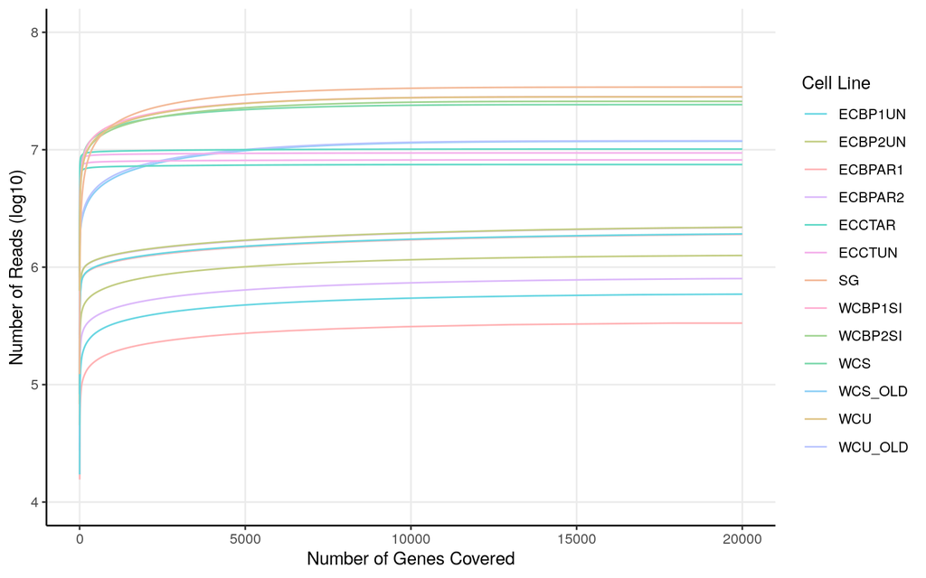

```r
# Define color palette
custom_palette <- qualitative_hcl(13, palette = "Set 3")
custom_palette <- sample(custom_palette, 13)

# Use SampleColouring from metadata
SampleColouring <- c("WCS_OLD", "WCU_OLD", "ECBPAR2", "ECBPAR2", "ECBPAR1", "ECBPAR1", "ECCTUN", "ECCTUN", "ECBP2UN", "ECBP2UN", "ECCTAR", "ECCTAR", "ECBP1UN", "ECBP1UN", "WCS", "WCBP2SI", "WCBP1SI", "SG", "WCU")

# Build cumulative counts
final <- sapply(1:ncol(read.counts), function(i) {
  sort_vals <- read.counts[order(read.counts[, i], decreasing = TRUE), i]
  cumsum(sort_vals)
})
final <- as.data.frame(final)
colnames(final) <- colnames(read.counts)

# Melt and add gene position + sample info
finalmelt <- reshape2::melt(final, variable.name = "Sample")
finalmelt$genes <- rep(1:nrow(final), times = ncol(final))
finalmelt$SampleColouring <- rep(SampleColouring, each = nrow(final))

# Plot cumulative read coverage
ggplot(data = finalmelt, aes(x = genes, y = log10(value), group = Sample, color = SampleColouring)) +
  geom_line() +
  scale_color_manual(values = custom_palette, name = "Cell Line") +
  theme_bw() +
  xlab("Number of Genes Covered") +
  ylab("Number of Reads (log10)") +
  xlim(0, 20000) +
  ylim(4, 8) +
  theme(
    axis.line = element_line(colour = "black"),
    panel.grid.minor = element_blank(),
    panel.border = element_blank(),
    panel.background = element_blank()
  )
```

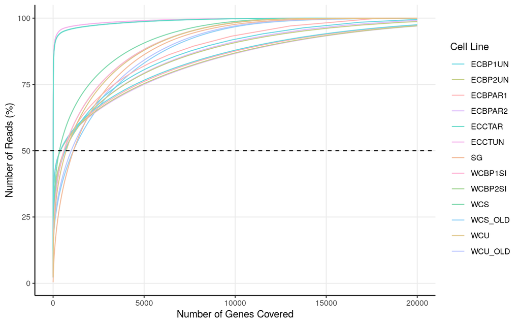

```r
# Create percentage-based plot
orderfinal <- subset(finalmelt, genes == max(finalmelt$genes))
trial <- merge(orderfinal[, c("Sample", "value")], finalmelt, by = "Sample", suffixes = c(".total", ".current"))
trial$percent <- (trial$value.current / trial$value.total) * 100
trial$SampleColouring <- rep(SampleColouring, each = nrow(final))

ggplot(data = trial, aes(x = genes, y = percent, group = Sample, color = SampleColouring)) +
  geom_line() +
  geom_hline(yintercept = 50, linetype = "dashed") +
  scale_color_manual(values = custom_palette, name = "Cell Line") +
  xlab("Number of Genes Covered") +
  ylab("Number of Reads (%)") +
  xlim(0, 20000) +
  theme_bw() +
  theme(
    axis.line = element_line(colour = "black"),
    panel.grid.minor = element_blank(),
    panel.border = element_blank(),
    panel.background = element_blank()
  )
```

As we can see in these plots, there are two sample types with much lower complexity, ECCTAR and ECCTUN

# Differential Expression Analysis

## Filtration

### *Before Filtration*

Let us begin with the filtration.

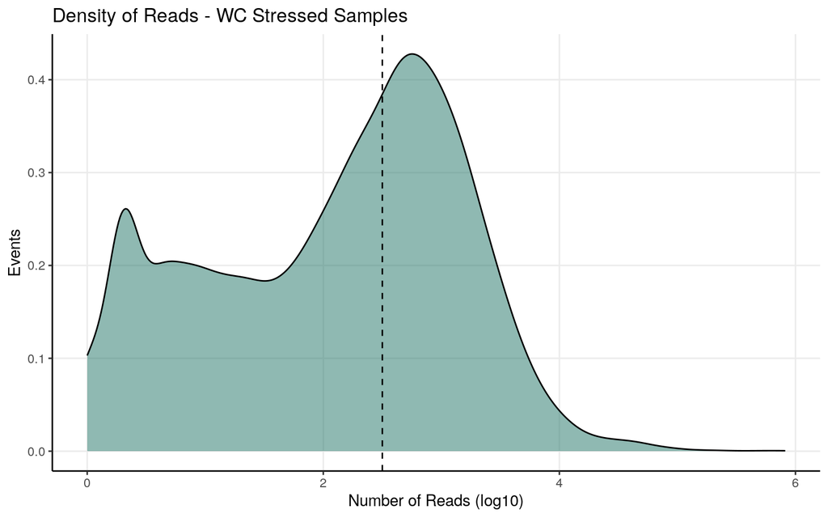

```r
alternew.WCS <- log10((read.counts[,c(15)]))
alternew.WCS <- as.data.frame(alternew.WCS)

alternew.WCU <- log10((read.counts[,c(19)]))
alternew.WCU <- as.data.frame(alternew.WCU)

alternew.ECBP2AR <- log10(rowSums(read.counts[,c(3,4)]))
alternew.ECBP2AR <- as.data.frame(alternew.ECBP2AR)

alternew.ECBP1AR <- log10(rowSums(read.counts[,c(5,6)]))
alternew.ECBP1AR <- as.data.frame(alternew.ECBP1AR)

alternew.ECCTUN <- log10(rowSums(read.counts[,c(7,8)]))
alternew.ECCTUN <- as.data.frame(alternew.ECCTUN)

alternew.ECBP2UN <- log10(rowSums(read.counts[,c(9,10)]))
alternew.ECBP2UN <- as.data.frame(alternew.ECBP2UN)

alternew.ECCTAR <- log10(rowSums(read.counts[,c(11,12)]))
alternew.ECCTAR <- as.data.frame(alternew.ECCTAR)

alternew.ECBP1UN <- log10(rowSums(read.counts[,c(13,14)]))
alternew.ECBP1UN <- as.data.frame(alternew.ECBP1UN)

alternew.WCBP2SI <- log10((read.counts[,c(16)]))
alternew.WCBP2SI <- as.data.frame(alternew.WCBP2SI)

alternew.WCBP1SI <- log10((read.counts[,c(17)]))
alternew.WCBP1SI <- as.data.frame(alternew.WCBP1SI)

alternew.SG <- log10((read.counts[,c(18)]))
alternew.SG <- as.data.frame(alternew.SG)

alternew <- log10(rowSums(read.counts))

alternew <- as.data.frame(alternew)

prefilt <- ggplot(alternew, aes(x=alternew)) + geom_density() + geom_vline(xintercept = 3.25, linetype = "dashed") + ylab("Density\n") + xlab("Number of Reads") + theme_classic() +
  theme(axis.line = element_line(colour = "black")) + ggtitle("Pre-Filtering")+
  theme(text=element_text(size=20,  family="Arial MS"))+
  scale_x_continuous(
    breaks = 1:6,
    labels = c("10", "100", expression(10^3),
               expression(10^4),
               expression(10^5),
               expression(10^6))
  )

ggplot(alternew.WCS, aes(x=alternew.WCS)) + geom_density(fill="#207567", alpha=0.5) + theme_bw() + geom_vline(xintercept = 2.5, linetype = "dashed") + ylab("Events") + xlab("Number of Reads (log10)") +
  theme(axis.line = element_line(colour = "black"),
        panel.grid.minor = element_blank(),
        panel.border = element_blank(),
        panel.background = element_blank()) + ggtitle("Density of Reads - WC Stressed Samples")
```

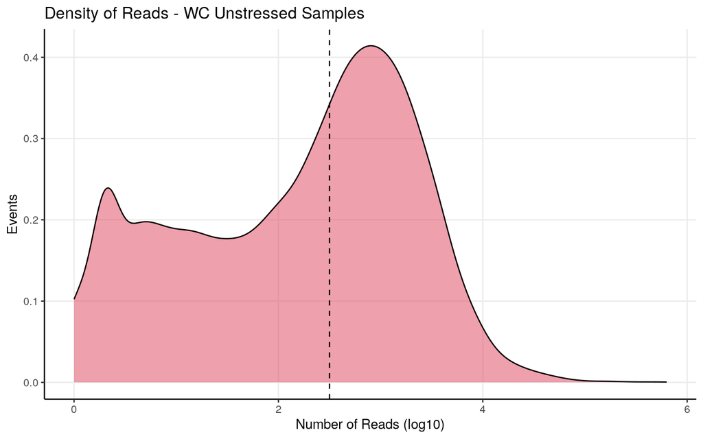

```r
ggplot(alternew.WCU, aes(x=alternew.WCU)) + geom_density(fill="#de425b", alpha=0.5) + theme_bw() + geom_vline(xintercept = 2.5, linetype = "dashed") + ylab("Events") + xlab("Number of Reads (log10)") +
  theme(axis.line = element_line(colour = "black"),
        panel.grid.minor = element_blank(),
        panel.border = element_blank(),
        panel.background = element_blank()) + ggtitle("Density of Reads - WC Unstressed Samples")
```

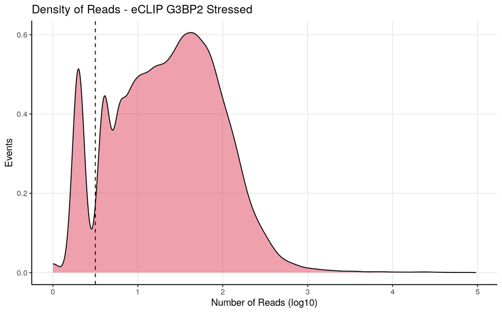

```r
ggplot(alternew.ECBP2AR, aes(x=alternew.ECBP2AR)) + geom_density(fill="#de425b", alpha=0.5) + theme_bw() + geom_vline(xintercept = 0.5, linetype = "dashed") + ylab("Events") + xlab("Number of Reads (log10)") +
  theme(axis.line = element_line(colour = "black"),
        panel.grid.minor = element_blank(),
        panel.border = element_blank(),
        panel.background = element_blank()) + ggtitle("Density of Reads - eCLIP G3BP2 Stressed")
```

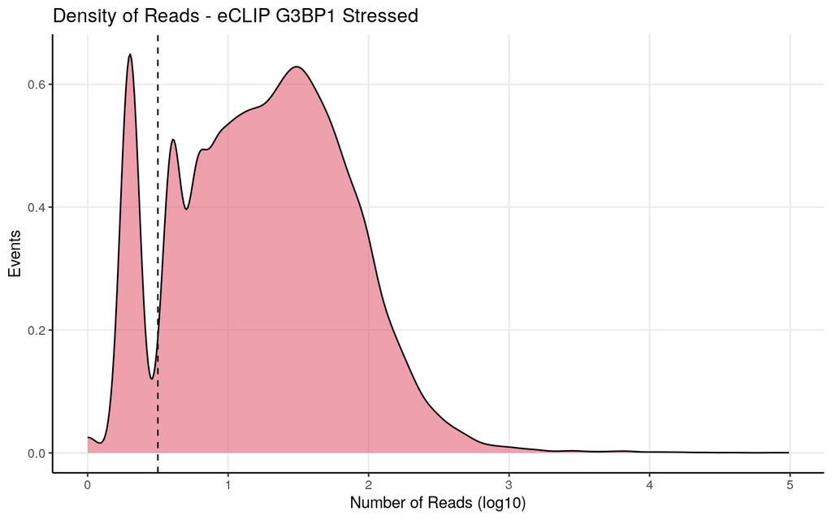

```r
ggplot(alternew.ECBP1AR, aes(x=alternew.ECBP1AR)) + geom_density(fill="#de425b", alpha=0.5) + theme_bw() + geom_vline(xintercept = 0.5, linetype = "dashed") + ylab("Events") + xlab("Number of Reads (log10)") +
  theme(axis.line = element_line(colour = "black"),
        panel.grid.minor = element_blank(),
        panel.border = element_blank(),
        panel.background = element_blank()) + ggtitle("Density of Reads - eCLIP G3BP1 Stressed")
```

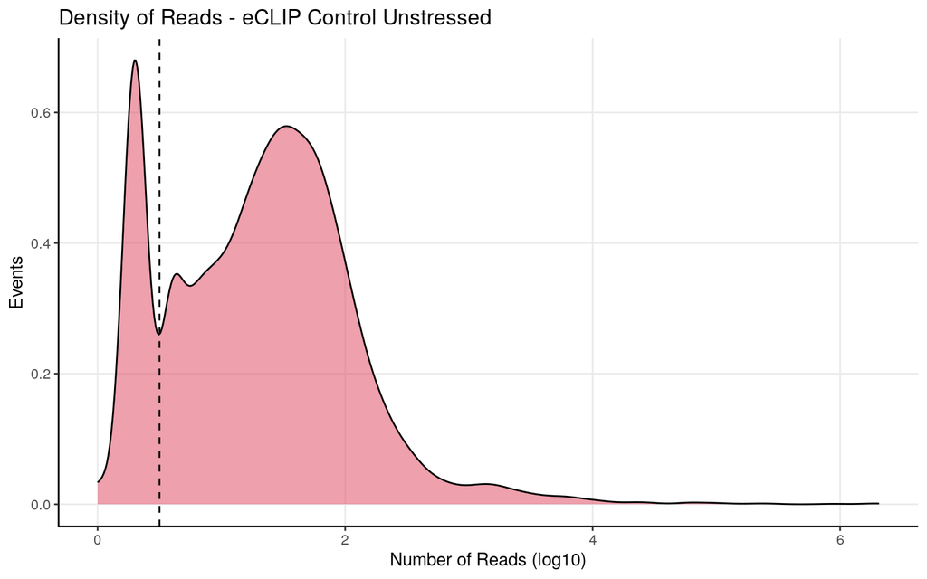

```r
ggplot(alternew.ECCTUN, aes(x=alternew.ECCTUN)) + geom_density(fill="#de425b", alpha=0.5) + theme_bw() + geom_vline(xintercept = 0.5, linetype = "dashed") + ylab("Events") + xlab("Number of Reads (log10)") +
  theme(axis.line = element_line(colour = "black"),
        panel.grid.minor = element_blank(),
        panel.border = element_blank(),
        panel.background = element_blank()) + ggtitle("Density of Reads - eCLIP Control Unstressed")
```

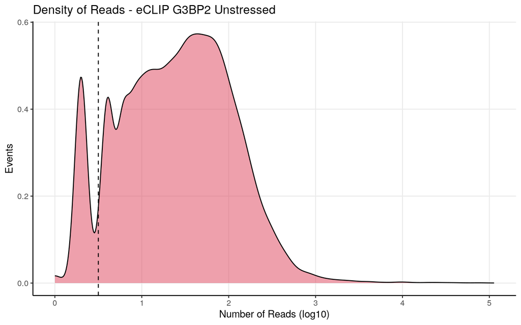

```r
ggplot(alternew.ECBP2UN, aes(x=alternew.ECBP2UN)) + geom_density(fill="#de425b", alpha=0.5) + theme_bw() + geom_vline(xintercept = 0.5, linetype = "dashed") + ylab("Events") + xlab("Number of Reads (log10)") +
  theme(axis.line = element_line(colour = "black"),
        panel.grid.minor = element_blank(),
        panel.border = element_blank(),
        panel.background = element_blank()) + ggtitle("Density of Reads - eCLIP G3BP2 Unstressed")
```

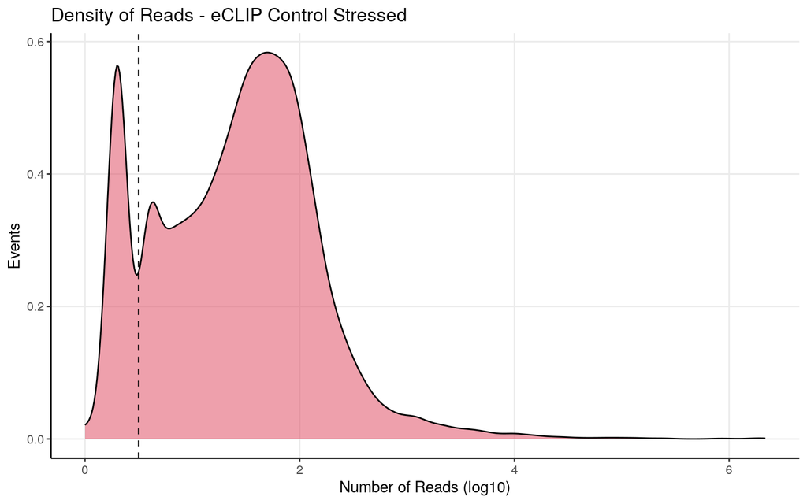

```r
ggplot(alternew.ECCTAR, aes(x=alternew.ECCTAR)) + geom_density(fill="#de425b", alpha=0.5) + theme_bw() + geom_vline(xintercept = 0.5, linetype = "dashed") + ylab("Events") + xlab("Number of Reads (log10)") +
  theme(axis.line = element_line(colour = "black"),
        panel.grid.minor = element_blank(),
        panel.border = element_blank(),
        panel.background = element_blank()) + ggtitle("Density of Reads - eCLIP Control Stressed")
```

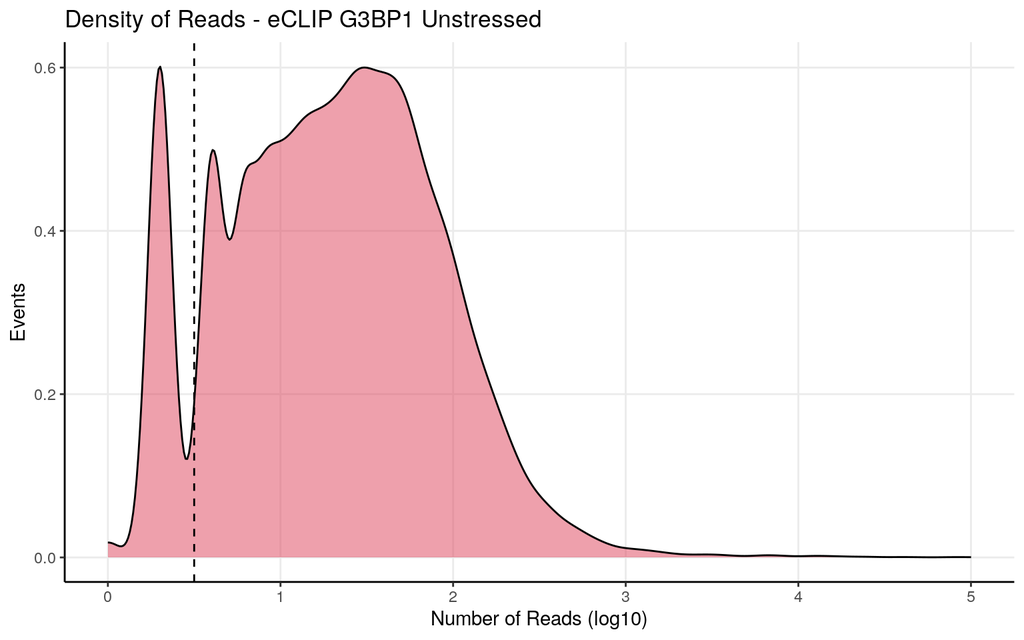

```r
ggplot(alternew.ECBP1UN, aes(x=alternew.ECBP1UN)) + geom_density(fill="#de425b", alpha=0.5) + theme_bw() + geom_vline(xintercept = 0.5, linetype = "dashed") + ylab("Events") + xlab("Number of Reads (log10)") +
  theme(axis.line = element_line(colour = "black"),
        panel.grid.minor = element_blank(),
        panel.border = element_blank(),
        panel.background = element_blank()) + ggtitle("Density of Reads - eCLIP G3BP1 Unstressed")
```

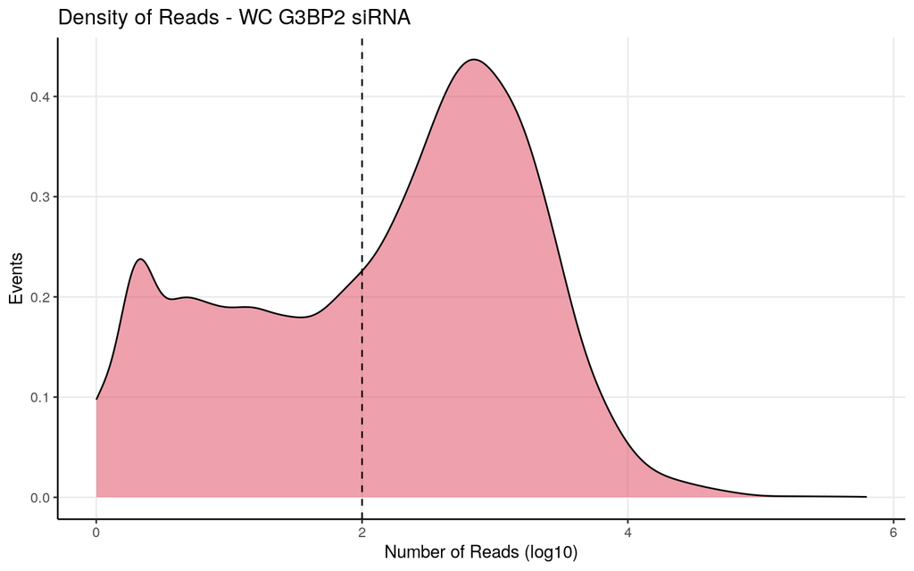

```r
ggplot(alternew.WCBP2SI, aes(x=alternew.WCBP2SI)) + geom_density(fill="#de425b", alpha=0.5) + theme_bw() + geom_vline(xintercept = 2, linetype = "dashed") + ylab("Events") + xlab("Number of Reads (log10)") +
  theme(axis.line = element_line(colour = "black"),
        panel.grid.minor = element_blank(),
        panel.border = element_blank(),
        panel.background = element_blank()) + ggtitle("Density of Reads - WC G3BP2 siRNA")
```

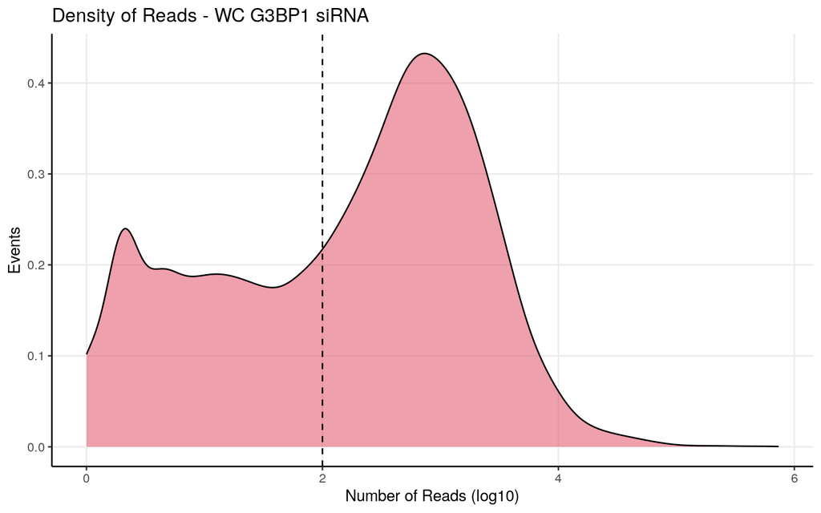

```r
ggplot(alternew.WCBP1SI, aes(x=alternew.WCBP1SI)) + geom_density(fill="#de425b", alpha=0.5) + theme_bw() + geom_vline(xintercept = 2, linetype = "dashed") + ylab("Events") + xlab("Number of Reads (log10)") +
  theme(axis.line = element_line(colour = "black"),
        panel.grid.minor = element_blank(),
        panel.border = element_blank(),
        panel.background = element_blank()) + ggtitle("Density of Reads - WC G3BP1 siRNA")
```

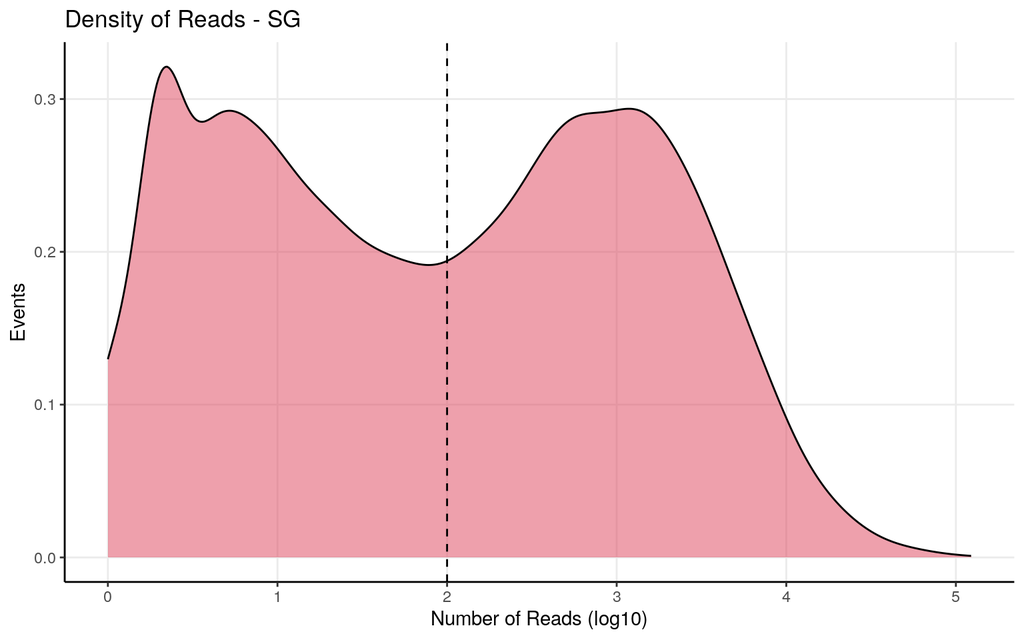

```r
ggplot(alternew.SG, aes(x=alternew.SG)) + geom_density(fill="#de425b", alpha=0.5) + theme_bw() + geom_vline(xintercept = 2, linetype = "dashed") + ylab("Events") + xlab("Number of Reads (log10)") +
  theme(axis.line = element_line(colour = "black"),
        panel.grid.minor = element_blank(),
        panel.border = element_blank(),
        panel.background = element_blank()) + ggtitle("Density of Reads - SG")
```

By seeing the shape of the graph, we can see where we should cut. We have a **binomial distribution** (low reads and noise vs actual biological meaningful reads). The ideal place to cut them is right before the wedge.

### *After Filtration*

While I usually filter all samples together, due to the problems in read depth and complexity, this time I considered it was more corrected to filter by sample type.

```r
filterednew <- subset(read.counts, alternew> 3.25)
filterednew.WCS <- subset(read.counts, alternew.WCS>2.5)
filterednew.WCU <- subset(read.counts, alternew.WCU>2.5)
filterednew.ECBP2AR <- subset(read.counts, alternew.ECBP2AR>0.5)
filterednew.ECBP1AR <- subset(read.counts, alternew.ECBP1AR>0.5)
filterednew.ECCTUN <- subset(read.counts, alternew.ECCTUN>0.5)
filterednew.ECBP2UN <- subset(read.counts, alternew.ECBP2UN>0.5)
filterednew.ECCTAR <- subset(read.counts, alternew.ECCTAR>0.5)
filterednew.ECBP1UN <- subset(read.counts, alternew.ECBP1UN>0.5)
filterednew.WCBP2SI <- subset(read.counts, alternew.WCBP2SI>2)
filterednew.WCBP1SI <- subset(read.counts, alternew.WCBP1SI>2)
filterednew.SG <- subset(read.counts, alternew.SG>2)

#after cutting, its a good idea to visualize again
falternew <- log10(rowSums(filterednew))
falternew <- as.data.frame(falternew)
postfilt <- ggplot(falternew, aes(x=falternew)) + geom_density() + ylab("Density\n") + xlab("Number of Reads") +
   theme_classic() +
  theme(axis.line = element_line(colour = "black"))+ ggtitle("Post-Filtering")+
  theme(text=element_text(size=20,  family="Arial MS")) +
  scale_x_continuous(
    breaks = 1:6,
    labels = c("10", "100", expression(10^3),
               expression(10^4),
               expression(10^5),
               expression(10^6))
  )

#lets save the genes which we maintain
impgenes <- c(row.names(falternew))
impgenes.WCS <- c(row.names(filterednew.WCS))
impgenes.WCU <- c(row.names(filterednew.WCU))
impgenes.ECBP2AR <- c(row.names(filterednew.ECBP2AR))
impgenes.ECBP1AR <- c(row.names(filterednew.ECBP1AR))
impgenes.ECCTAR <- c(row.names(filterednew.ECCTAR))
impgenes.ECCTUN <- c(row.names(filterednew.ECCTUN))
impgenes.ECBP2UN <- c(row.names(filterednew.ECBP2UN))
impgenes.ECBP1UN <- c(row.names(filterednew.ECBP1UN))
impgenes.WCBP2SI <- c(row.names(filterednew.WCBP2SI))
impgenes.WCBP1SI <- c(row.names(filterednew.WCBP1SI))
impgenes.SG <- c(row.names(filterednew.SG))

#Now we need to select only the rows which have those genes.
finaltable <- read.counts[row.names(read.counts)%in%impgenes,]
finaltable <- finaltable[row.names(finaltable)%in%impgenes.WCS,]
finaltable <- finaltable[row.names(finaltable)%in%impgenes.WCU,]
finaltable <- finaltable[row.names(finaltable)%in%impgenes.ECBP2AR,]
finaltable <- finaltable[row.names(finaltable)%in%impgenes.ECBP1AR,]
finaltable <- finaltable[row.names(finaltable)%in%impgenes.ECCTAR,]
finaltable <- finaltable[row.names(finaltable)%in%impgenes.ECCTUN,]
finaltable <- finaltable[row.names(finaltable)%in%impgenes.ECBP2UN,]
finaltable <- finaltable[row.names(finaltable)%in%impgenes.ECBP1UN,]
finaltable <- finaltable[row.names(finaltable)%in%impgenes.WCBP2SI,]
finaltable <- finaltable[row.names(finaltable)%in%impgenes.WCBP1SI,]
finaltable <- finaltable[row.names(finaltable)%in%impgenes.SG,]
```

[output not shown]

[output cut: 111 more lines]

[output not shown]

[output not shown]

[output not shown]

[output cut: 51 more lines]

[output not shown]

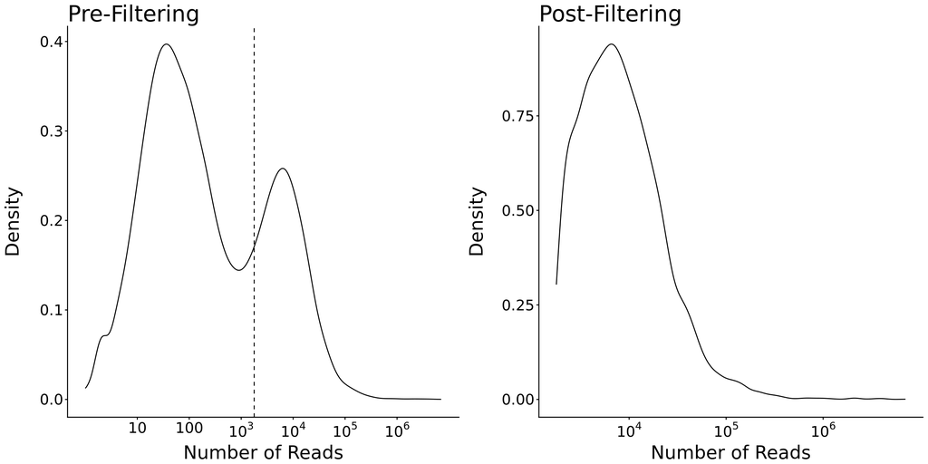

```r
(filtplot <- ggarrange(prefilt, postfilt, nrow=1))
```

```r
png("~/Images/Filt_Example.png", width = 14, height=4, units = "in", res=300)
filtplot
dev.off()
```

## Matrices

Good! Now we can proceed by designing our matrices.

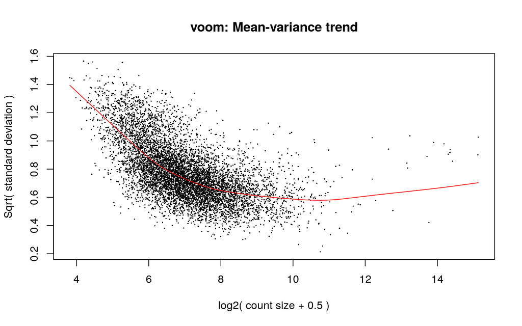

```r
#Let us prepare metadata to add to our samples

#To be able to use Voom, we must first convert our read count table into a special DGE object.
D0 <- DGEList(finaltable)

#Then we calculate the normalization factors.
#Bear in mind this step calculates the normalization factors, but does not normalize itself.
D0 <- calcNormFactors(D0)

#Now we do our matrix itself
mm <- model.matrix(~0+SampleColouring)

#and now we normalize. This step also turns our counts into log2-counts per million.
y <- voom(D0, mm, plot = T)
```

## Normalisation

For normalisation I convert the read counts into log2CPMs. Its a good way to visualise how the reads are.

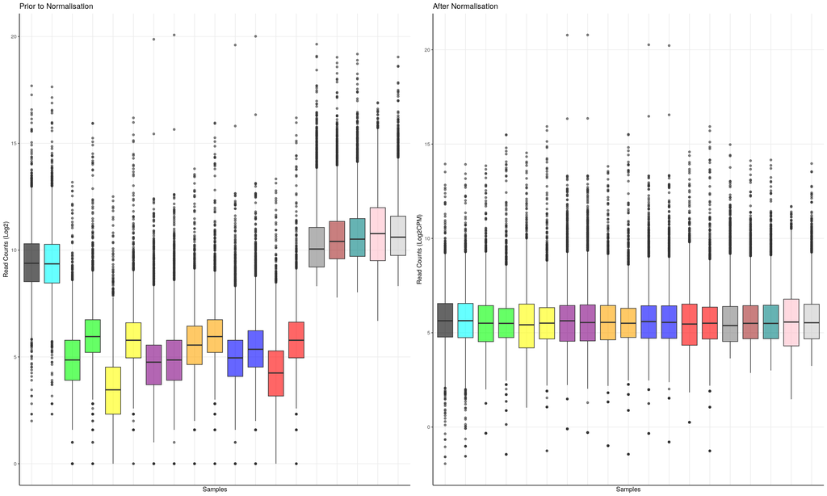

```r
dfforboxy <- finaltable

orderforplots <- SampleColouring
colouring <- data.frame(Sample=colnames(dfforboxy), Types=orderforplots)
dfforboxy <- reshape2::melt(dfforboxy)
colnames(dfforboxy) <- c("Sample", "Expression")
dfforboxy <- merge(dfforboxy, colouring, by="Sample")
prenorm <- ggplot(dfforboxy, aes(x=Sample, y=(log2(Expression+1)), fill=Types)) + geom_boxplot(alpha=0.6) + theme_bw() + ylab("Read Counts (Log2)") + xlab("Samples") + scale_fill_manual(name = "Sample Type", values = c("#FF0000", "#FFA500", "#FFFF00", "#00FF00", "#0000FF", "#800080", "#FFC0CB", "#008080", "#A52A2A","#808080","#000000","#CCCCCC","#00FFFF"), labels=unique(orderforplots)) +
  theme(axis.line = element_line(colour = "black"),
        panel.grid.minor = element_blank(),
        panel.border = element_blank(),
        panel.background = element_blank(),
        axis.text.x=element_blank(),
        axis.ticks.x=element_blank(),
        legend.position = "None") + ggtitle("Prior to Normalisation")

#Using the Standard Matrix

dfforboxy <- y$E
dfforboxy <- reshape2::melt(dfforboxy)
dfforboxy <- dfforboxy[,-1]
colnames(dfforboxy) <- c("Sample", "Expression")
dfforboxy <- merge(dfforboxy, colouring, by="Sample")
postnorm <- ggplot(dfforboxy, aes(x=Sample, y=Expression, fill=Types)) + geom_boxplot(alpha=0.6) + theme_bw() + ylab("Read Counts (Log2CPM)") + xlab("Samples") + scale_fill_manual(name = "Sample Type", values = c("#FF0000", "#FFA500", "#FFFF00", "#00FF00", "#0000FF", "#800080", "#FFC0CB", "#008080", "#A52A2A","#808080","#000000","#CCCCCC","#00FFFF"), labels=unique(orderforplots)) +
  theme(axis.line = element_line(colour = "black"),
        panel.grid.minor = element_blank(),
        panel.border = element_blank(),
        panel.background = element_blank(),
        axis.text.x=element_blank(),
        axis.ticks.x=element_blank(),
        legend.position = "None") + ggtitle("After Normalisation")

ggarrange(prenorm, postnorm, nrow=1)
```

The normalisation has some issues, but looking at the differences in read depth, it was to be expected.

## PCA

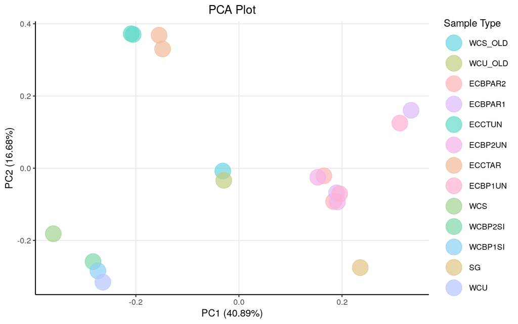

```r
#this is done to be able to do traditional PCA
dfforpca <- y$E
dfforpca <- rbind(dfforpca, SampleColouring)
dfforpca <- t(dfforpca)
numcol <- c(1:(ncol(dfforpca)-1))
dfforpca <- as.data.frame(dfforpca) #for some reason I can only change colum type if its a dataframe

dfforpca[ ,numcol] <- apply(dfforpca[ , numcol], 2,            # to turn our columns into numeric
                            function(x) as.numeric(as.character(x)))

#sapply(dfforpca, class) #to check class

# Or specify the factor levels in the order you want
dfforpca$SampleColouring <- factor(dfforpca$SampleColouring, levels = unique(SampleColouring))

pca_res <- prcomp(dfforpca[,numcol], scale=FALSE) #prepare the pca

#to make everything pretty
p <- autoplot(pca_res, data = dfforpca, x=1, y=2, colour = "SampleColouring", size=8, alpha=0.7)
p <- p + theme_bw() + scale_colour_manual(name = "Sample Type", values = custom_palette, labels=c(unique(SampleColouring)))
p <- p + ggtitle("PCA Plot") + theme(plot.title = element_text(hjust = 0.5)) +
  theme(axis.line = element_line(colour = "black"),
        panel.grid.minor = element_blank(),
        panel.border = element_blank(),
        panel.background = element_blank())
p
```

```r
#in case you want to see them yourself
contribs1 <- pca_res$rotation[,1]
contribs2 <- pca_res$rotation[,2]

#These are the biggest contributors to the PCA1 (right side)
(pos1genes <- sort(contribs1, decreasing=T)[1:10])
```

```
##      PLBD2     MBTPS2     TNRC18     POLR2A      BASP1      TMOD3      SUZ12
## 0.05197582 0.04273632 0.04084673 0.03952813 0.03864803 0.03795232 0.03685034
##       SDK1      MKLN1     POU2F1
## 0.03543350 0.03537581 0.03508963
```

```r
#These are the biggest contributors to the PCA1 (left side)
(neg1genes <- sort(contribs1, decreasing=F)[1:10])
```

```
##         MIF     MIF-AS1       RPS28        RPS2       RPL32     MIR1282
## -0.04820622 -0.04815711 -0.04403484 -0.04118169 -0.04076258 -0.04063753
##       COX8A       RPS17       RPS26      RPL18A
## -0.04043907 -0.03998019 -0.03988661 -0.03985760
```

```r
#These are the biggest contributors to the PCA2 (up side)
(pos2genes <- sort(contribs2, decreasing=T)[1:10])
```

```
##      WDR74     MT-TL1     SNHG15      MT-TH      DANCR      SNHG1     SNHG11
## 0.14304440 0.09525594 0.07508028 0.07483139 0.07005734 0.06674700 0.05975414
##     H2BC12      SNHG7     SNHG17
## 0.05942897 0.05368776 0.05302638
```

```r
#These are the biggest contributors to the PCA2 (down side)
(neg2genes <- sort(contribs2, decreasing=F)[1:10])
```

```
##        DMTN      CYB5R3      CLDN15       PIDD1       BRSK2      DCAF15
## -0.04315242 -0.03999777 -0.03963825 -0.03952412 -0.03880115 -0.03799765
##      ZNF579      RNF208        DTX1       SMAD6
## -0.03754706 -0.03706570 -0.03679988 -0.03633831
```

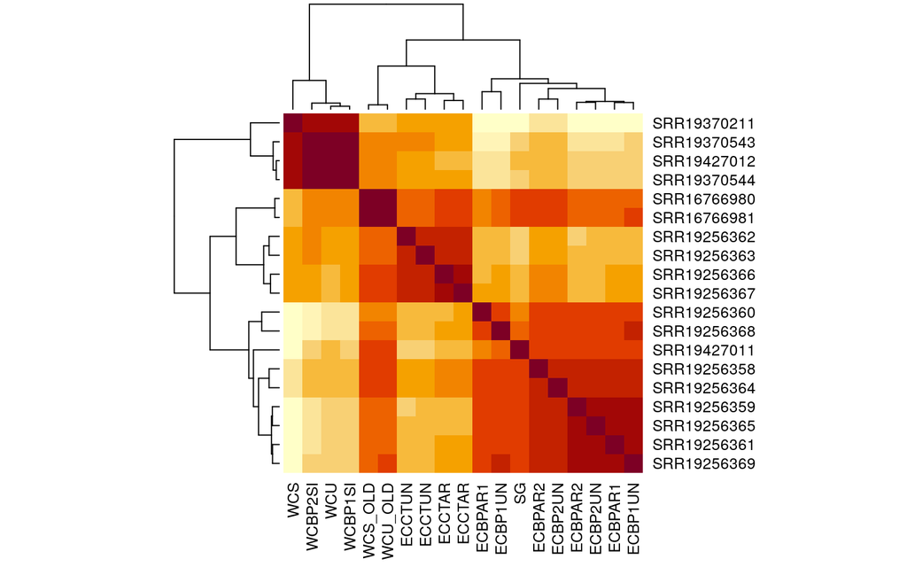

```r
heatmap(cor(y$E, method="spearman"), symm=T, labRow = colnames(y$E), labCol = SampleColouring)
```

From the PCA we can see that the two versions of WCU and WCS do not appear close in the plot. For simplicity’s sake, I opted to remove the old version of these samples. As we can see from the heatmap, excluding the controls, the differences between eCLIP samples appears to be minimal.

# Simple Linear Models

Now we must perform linear model fitting.

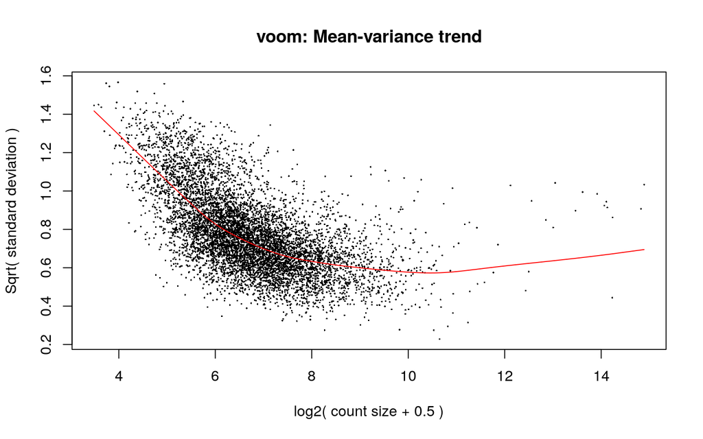

```r
#Removing the old samples
D0 <- DGEList(finaltable[,-c(1:2)])

#Then we calculate the normalization factors.
#Bear in mind this step calculates the normalization factors, but does not normalize itself.
D0 <- calcNormFactors(D0)

fordescriptive <- c("WCS_OLD", "WCU_OLD", "ECBPAR2", "ECBPAR2", "ECBPAR1", "ECBPAR1", "ECCTUN", "ECCTUN", "ECBP2UN", "ECBP2UN", "ECCTAR", "ECCTAR", "ECBP1UN", "ECBP1UN", "WCS", "WCBP2SI", "WCBP1SI", "SG", "WCU")[-c(1:2)]

fortype <- c("WC", "WC", "EC", "EC", "EC", "EC", "EC", "EC", "EC", "EC", "EC", "EC", "EC", "EC", "WC", "WC", "WC", "SG", "WC")

forstress <- c("YES", "NO", "YES", "YES", "YES", "YES", "NO", "NO", "NO", "NO", "YES", "YES", "NO", "NO", "YES", "NO", "NO", "YES", "NO")

fortarget <- c("NO", "NO", "G3BP2", "G3BP2", "G3BP1", "G3BP1", "CT", "CT", "G3BP2", "G3BP2", "CT", "CT", "G3BP1", "G3BP1", "NO", "NO", "NO", "NO", "NO")

forsg <- c("NO", "NO", "YES", "YES", "YES", "YES", "NO", "NO", "NO", "NO", "NO", "NO", "NO", "NO", "NO", "NO", "NO", "YES", "NO")

#Now we do our matrix itself
mm <- model.matrix(~0+fordescriptive)

#and now we normalize. This step also turns our counts into log2-counts per million.
y <- voom(D0, mm, plot = T)
```

```r
fitted_y <- lmFit(y, mm)


#Just to see if everything is ok
head(coef(fitted_y))
```

```
##       fordescriptiveECBP1UN fordescriptiveECBP2UN fordescriptiveECBPAR1
## A1BG               4.401405              3.720531              4.167243
## AAAS               5.357723              5.192823              3.171438
## AACS               4.667990              5.129919              4.882107
## AADAT              3.658967              4.035435              4.319913
## AAGAB              4.790387              4.574981              4.786578
## AAK1               7.688474              7.562108              7.617835
##       fordescriptiveECBPAR2 fordescriptiveECCTAR fordescriptiveECCTUN
## A1BG               4.254137             3.725840             3.204638
## AAAS               5.309718             5.433078             5.657917
## AACS               3.740083             3.270203             3.663407
## AADAT              3.817178             4.549822             3.550577
## AAGAB              4.991727             6.269122             5.992325
## AAK1               7.282369             6.045516             6.281814
##       fordescriptiveSG fordescriptiveWCBP1SI fordescriptiveWCBP2SI
## A1BG          3.320260              4.150711              3.959596
## AAAS          4.815696              6.332400              6.347446
## AACS          4.248177              4.548414              4.428040
## AADAT         4.599551              4.138982              4.138302
## AAGAB         4.920191              4.786555              5.004296
## AAK1          8.169474              4.789559              4.868119
##       fordescriptiveWCS fordescriptiveWCU
## A1BG           4.163929          4.060238
## AAAS           6.658719          6.260456
## AACS           4.796348          4.466822
## AADAT          4.206860          3.949114
## AAGAB          5.336100          4.962238
## AAK1           4.122887          4.978323
```

```r
#Lets do the comparisons
SG.vs.WC <- makeContrasts(fordescriptiveSG  - fordescriptiveWCS , levels=colnames(coef(fitted_y)))
BP1.vs.CT <- makeContrasts(fordescriptiveECBPAR1   - fordescriptiveECCTAR  , levels=colnames(coef(fitted_y)))
BP2.vs.CT <- makeContrasts(fordescriptiveECBPAR2 - fordescriptiveECCTAR , levels=colnames(coef(fitted_y)))
BP1.vs.BP1 <- makeContrasts(fordescriptiveECBPAR1  - fordescriptiveECBP1UN   , levels=colnames(coef(fitted_y)))
BP2.vs.BP2 <- makeContrasts(fordescriptiveECBPAR2  - fordescriptiveECBP2UN   , levels=colnames(coef(fitted_y)))


tmp_SG.vs.WC <- contrasts.fit(fitted_y, SG.vs.WC)
tmp_BP1.vs.CT <- contrasts.fit(fitted_y, BP1.vs.CT)
tmp_BP2.vs.CT <- contrasts.fit(fitted_y, BP2.vs.CT)
tmp_BP1.vs.BP1 <- contrasts.fit(fitted_y, BP1.vs.BP1)
tmp_BP2.vs.BP2 <- contrasts.fit(fitted_y, BP2.vs.BP2)



tmp_SG.vs.WC <- eBayes(tmp_SG.vs.WC)
tmp_BP1.vs.CT <- eBayes(tmp_BP1.vs.CT)
tmp_BP2.vs.CT <- eBayes(tmp_BP2.vs.CT)
tmp_BP1.vs.BP1 <- eBayes(tmp_BP1.vs.BP1)
tmp_BP2.vs.BP2 <- eBayes(tmp_BP2.vs.BP2)
```

```r
eclip_groups <- c("ECBPAR1", "ECBPAR2", "ECCTUN", "ECBP2UN", "ECCTAR", "ECBP1UN")
eclip_idx <- which(fordescriptive %in% eclip_groups)

cormat <- cor(y$E[, eclip_idx], method = "spearman")
colnames(cormat) <- rownames(cormat) <- fordescriptive[eclip_idx]
sample_names <- colnames(y$E)[eclip_idx]

result <- do.call(rbind, lapply(seq_along(eclip_idx), function(i) {
  own_group <- fordescriptive[eclip_idx][i]
  partner_idx <- which(fordescriptive[eclip_idx] == own_group & seq_along(eclip_idx) != i)

  own_cor <- cormat[i, partner_idx]

  others <- cormat[i, -c(i, partner_idx)]
  best_other_cor <- max(others)
  best_other_group <- names(others)[which.max(others)]

  data.frame(
    Sample = sample_names[i],
    Group = own_group,
    OwnReplicateCor = own_cor,
    BestOtherCor = best_other_cor,
    BestOtherGroup = best_other_group,
    Mismatched = best_other_cor > own_cor
  )
}))

result[order(-result$Mismatched, result$OwnReplicateCor), ]
```

```
##         Sample   Group OwnReplicateCor BestOtherCor BestOtherGroup Mismatched
## 3  SRR19256360 ECBPAR1       0.7520517    0.7590739        ECBP1UN       TRUE
## 4  SRR19256361 ECBPAR1       0.7520517    0.9031241        ECBP1UN       TRUE
## 12 SRR19256369 ECBP1UN       0.7985693    0.9031241        ECBPAR1       TRUE
## 1  SRR19256358 ECBPAR2       0.8090423    0.8624963        ECBP2UN       TRUE
## 2  SRR19256359 ECBPAR2       0.8090423    0.9000058        ECBP2UN       TRUE
## 7  SRR19256364 ECBP2UN       0.8377266    0.8624963        ECBPAR2       TRUE
## 8  SRR19256365 ECBP2UN       0.8377266    0.9000058        ECBPAR2       TRUE
## 11 SRR19256368 ECBP1UN       0.7985693    0.7934012        ECBP2UN      FALSE
## 5  SRR19256362  ECCTUN       0.8506473    0.8373968         ECCTAR      FALSE
## 6  SRR19256363  ECCTUN       0.8506473    0.8433021         ECCTAR      FALSE
## 9  SRR19256366  ECCTAR       0.8768034    0.8341078         ECCTUN      FALSE
## 10 SRR19256367  ECCTAR       0.8768034    0.8433021         ECCTUN      FALSE
```

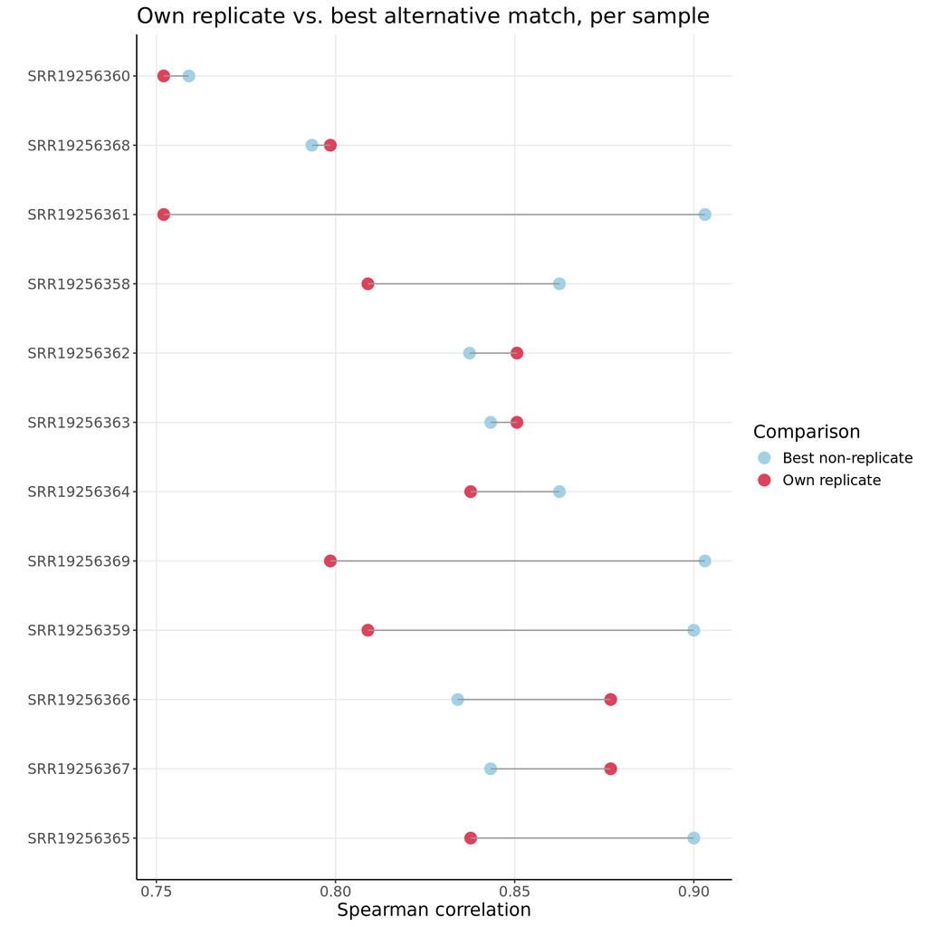

```r
result_long <- rbind(
  data.frame(Sample = result$Sample, Correlation = result$OwnReplicateCor, Comparison = "Own replicate"),
  data.frame(Sample = result$Sample, Correlation = result$BestOtherCor, Comparison = "Best non-replicate")
)

ggplot(result_long, aes(x = reorder(Sample, -Correlation), y = Correlation, color = Comparison)) +
  geom_point(size = 4) +
  geom_line(aes(group = Sample), color = "grey60") +
  coord_flip() +
  scale_color_manual(values = c("Own replicate" = "#de425b", "Best non-replicate" = "#a2d1e6")) +
  theme_bw() +
  ylab("Spearman correlation") + xlab("") +
  ggtitle("Own replicate vs. best alternative match, per sample") +
  theme(axis.line = element_line(colour = "black"),
        panel.grid.minor = element_blank(),
        panel.border = element_blank(),
        panel.background = element_blank(),
        text = element_text(size = 14, family = "Arial MS"))
```

[output not shown]

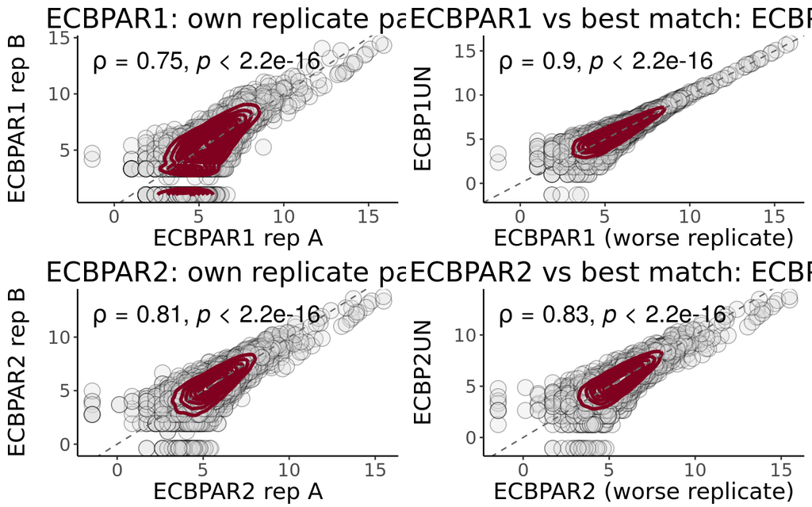

```r
plot_pair <- function(sample1, sample2, label1, label2, title) {
  df <- data.frame(Rep1 = y$E[, sample1], Rep2 = y$E[, sample2])

  ggplot(df, aes(x = Rep1, y = Rep2)) +
    geom_point(fill = "#DDDDDD", alpha = 0.3, size = 5, shape = 21, colour = 'black') +
    geom_density2d(color = "#800020", size = 1.2) +
    geom_abline(slope = 1, intercept = 0, linetype = "dashed", color = "grey40") +
    theme_bw() +
    ylab(paste0(label2, "\n")) + xlab(label1) +
    ggtitle(title) +
    theme(axis.line = element_line(colour = "black"),
          panel.grid.minor = element_blank(),
          panel.border = element_blank(),
          panel.background = element_blank()) +
    theme(plot.title = element_text(hjust = 0.5)) +
    theme(text = element_text(size = 16, family = "Arial MS")) +
    stat_cor(method = "spearman", cor.coef.name = "rho", size = 6) +
    theme(panel.grid.major = element_blank(), panel.grid.minor = element_blank())
}

## ---- Find the specific "best other sample," not just the group ----------
get_best_match <- function(group_name) {
  idx <- which(fordescriptive[eclip_idx] == group_name)
  # Pull the worse-behaving sample of the pair (lower own-replicate cor)
  own_cors <- sapply(idx, function(i) {
    partner <- which(fordescriptive[eclip_idx] == group_name & seq_along(eclip_idx) != i)
    cormat[i, partner]
  })
  worst_i <- idx[which.min(own_cors)]
  own_partner_i <- idx[idx != worst_i]

  others <- cormat[worst_i, -c(worst_i, own_partner_i)]
  best_other_i <- which(colnames(cormat) == names(others)[which.max(others)])
  # colnames(cormat) are group labels, not sample names — map back via position
  best_other_pos <- which(cormat[worst_i, ] == max(others))
  best_other_pos <- best_other_pos[!(best_other_pos %in% c(worst_i, own_partner_i))][1]

  list(
    worst_sample   = sample_names[worst_i],
    own_partner    = sample_names[own_partner_i],
    best_other     = sample_names[best_other_pos],
    best_other_grp = fordescriptive[eclip_idx][best_other_pos]
  )
}

bp1 <- get_best_match("ECBPAR1")
bp2 <- get_best_match("ECBPAR2")

## ---- ECBPAR1: own replicate pair, and vs its best non-replicate match ---
p1a <- plot_pair(bp1$own_partner, bp1$worst_sample, "ECBPAR1 rep A", "ECBPAR1 rep B",
                  "ECBPAR1: own replicate pair")
p1b <- plot_pair(bp1$own_partner, bp1$best_other, "ECBPAR1 (worse replicate)", bp1$best_other_grp,
                  paste0("ECBPAR1 vs best match: ", bp1$best_other_grp))

## ---- ECBPAR2: same ----
p2a <- plot_pair(bp2$own_partner, bp2$worst_sample, "ECBPAR2 rep A", "ECBPAR2 rep B",
                  "ECBPAR2: own replicate pair")
p2b <- plot_pair(bp2$own_partner, bp2$best_other, "ECBPAR2 (worse replicate)", bp2$best_other_grp,
                  paste0("ECBPAR2 vs best match: ", bp2$best_other_grp))

ggpubr::ggarrange(p1a, p1b, p2a, p2b, ncol = 2, nrow = 2)
```

```r
get_original_label <- function(sample_id) {
  # sample_id can be a column name or a numeric/position index into y$E
  if (is.character(sample_id) && sample_id %in% colnames(read.counts)) {
    return(sample_id)
  }
  # Fallback: match by position (same column order between read.counts and y$E)
  pos <- if (is.character(sample_id)) which(colnames(y$E) == sample_id) else sample_id
  colnames(read.counts)[pos]
}

plot_pair <- function(sample1, sample2, title) {
  df <- data.frame(Rep1 = y$E[, sample1], Rep2 = y$E[, sample2])

  label1 <- get_original_label(sample1)
  label2 <- get_original_label(sample2)

  ggplot(df, aes(x = Rep1, y = Rep2)) +
    geom_point(fill = "#DDDDDD", alpha = 0.3, size = 5, shape = 21, colour = 'black') +
    geom_density2d(color = "#800020", size = 1.2) +
    geom_abline(slope = 1, intercept = 0, linetype = "dashed", color = "grey40") +
    theme_bw() +
    ylab(paste0(label2, "\n")) + xlab(label1) +
    ggtitle(title) +
    theme(axis.line = element_line(colour = "black"),
          panel.grid.minor = element_blank(),
          panel.border = element_blank(),
          panel.background = element_blank()) +
    theme(plot.title = element_text(hjust = 0.5)) +
    theme(text = element_text(size = 16, family = "Arial MS")) +
    stat_cor(method = "spearman", cor.coef.name = "rho", size = 6) +
    theme(panel.grid.major = element_blank(), panel.grid.minor = element_blank())
}

## ---- ECBPAR1 ----
p1a <- plot_pair(bp1$own_partner, bp1$worst_sample, "ECBPAR1: own replicate pair")
p1b <- plot_pair(bp1$own_partner, bp1$best_other, paste0("ECBPAR1 vs best match: ", bp1$best_other_grp))

## ---- ECBPAR2 ----
p2a <- plot_pair(bp2$own_partner, bp2$worst_sample, "ECBPAR2: own replicate pair")
p2b <- plot_pair(bp2$own_partner, bp2$best_other, paste0("ECBPAR2 vs best match: ", bp2$best_other_grp))

p_corr <- ggpubr::ggarrange(p1a, p1b, p2a, p2b, ncol = 2, nrow = 2)
```

[output not shown]

[output cut: 11 more lines]

[output not shown]

```r
png("~/Projects/StressGranules/SGPAPER/Images/PNG/KSato.png", width = 14, height=12, units = "in", res=300)
p_corr
dev.off()
```

```r
#TOP Tables
top_SG.vs.WC <- topTable(tmp_SG.vs.WC, sort.by = "logFC", n=Inf)
top_BP1.vs.CT <- topTable(tmp_BP1.vs.CT, sort.by = "logFC", n=Inf)
top_BP2.vs.CT <- topTable(tmp_BP2.vs.CT, sort.by = "logFC", n=Inf)
top_BP1.vs.BP1 <- topTable(tmp_BP1.vs.BP1, sort.by = "logFC", n=Inf)
top_BP2.vs.BP2 <- topTable(tmp_BP2.vs.BP2, sort.by = "logFC", n=Inf)


#DEGenes
DEGenes_SG.vs.WC <- top_SG.vs.WC
DEGenes_BP1.vs.CT <- top_BP1.vs.CT
DEGenes_BP2.vs.CT<- top_BP2.vs.CT
DEGenes_BP1.vs.BP1<- top_BP1.vs.BP1
DEGenes_BP2.vs.BP2<- top_BP2.vs.BP2
```

# G3BP1 eclip vs Control (stressed)

## Volcano Plot

As G3BP1 is usually the protein that is used for DC and PL based purification, this is the comparison that I used for my heatmap.

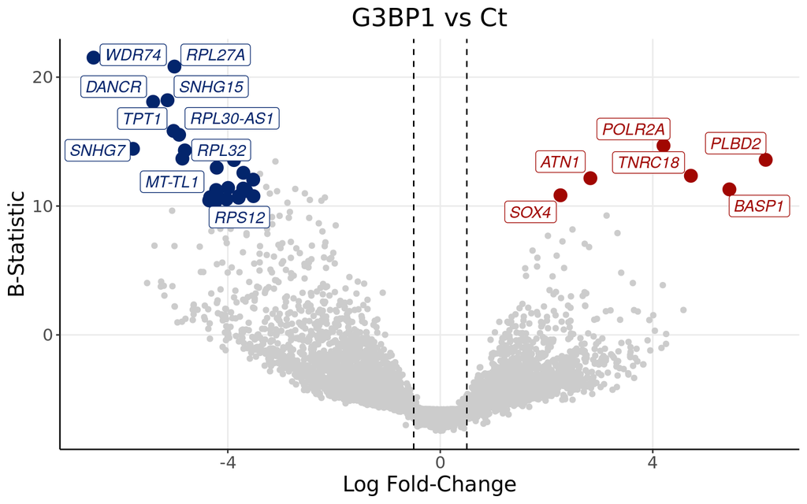

```r
write.table(DEGenes_BP1.vs.CT, "~/Projects/StressGranules/SGPAPER/RealSGs/AlzhEclip.txt", row.names = T)
ndegs <- 10
upmarkers <- as.data.frame(DEGenes_BP1.vs.CT[DEGenes_BP1.vs.CT$logFC>2 & DEGenes_BP1.vs.CT$B>10,] )
downmarkers <- as.data.frame(DEGenes_BP1.vs.CT[DEGenes_BP1.vs.CT$logFC< -3.5 & DEGenes_BP1.vs.CT$B>10,] )

ggplot(data=DEGenes_BP1.vs.CT,
                 aes(x=logFC,
                     y=  B)) +
  geom_point(color="#CCCCCC")+ geom_vline(xintercept = -0.5, linetype="dashed")+geom_vline(xintercept = 0.5, linetype="dashed")+
  theme_bw() + ylab("B-Statistic")+xlab("Log Fold-Change")+
  theme(axis.line = element_line(colour = "black"),
        panel.grid.minor = element_blank(),
        panel.border = element_blank(),
        panel.background = element_blank()) +
  ggtitle("G3BP1 vs Ct")+
  theme(plot.title = element_text(hjust = 0.5), plot.subtitle = element_text(hjust = 0.5)) +
  geom_point(data=upmarkers, aes(x=logFC, y=  B), color="#A10702",size=4)+
  geom_point(data=downmarkers, aes(x=logFC, y=  B), color="#03256C",size=4)+
  geom_label_repel(upmarkers[1:ndegs,] , mapping=aes(label=row.names(upmarkers)[1:ndegs]),size=4,point.padding=-0.5, color="#A10702",max.overlaps = 20, fontface="italic")+
  geom_label_repel(downmarkers[1:ndegs,] , mapping=aes(label=row.names(downmarkers)[1:ndegs]),size=4,point.padding=-0.5, color="#03256C",max.overlaps = 20, fontface="italic")+
  theme(text=element_text(size=15,  family="Arial MS"))
```

## Volcano Plot with Gene Length

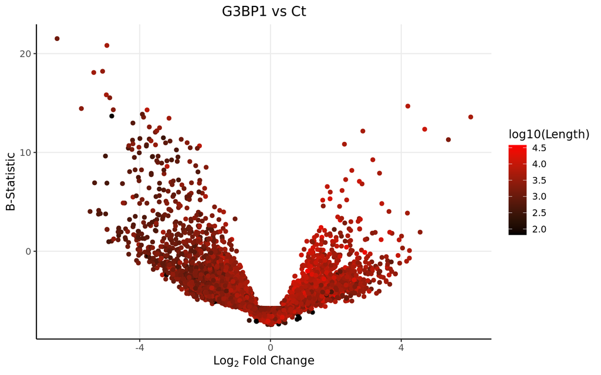

```r
DEGenes_BP1.vs.CT$Gene <- row.names(DEGenes_BP1.vs.CT)
colnames(genelength) <- c("Length","Gene")
DEGenes_BP1.vs.CT <- merge(DEGenes_BP1.vs.CT, genelength, by="Gene")

ggplot(data=DEGenes_BP1.vs.CT,
                 aes(x=logFC,
                     y=  B)) +
  geom_point(aes(color=log10(Length)))+
  theme_bw() +
  theme(axis.line = element_line(colour = "black"),
        panel.grid.minor = element_blank(),
        panel.border = element_blank(),
        panel.background = element_blank()) +
  ggtitle("G3BP1 vs Ct")+ xlab(expression(Log[2] ~ Fold ~ Change)) + ylab("B-Statistic") +
  theme(plot.title = element_text(hjust = 0.5))  +
  scale_colour_gradient(low = "black", high = "red")+ theme(text=element_text(family = "Quicksand"))
```

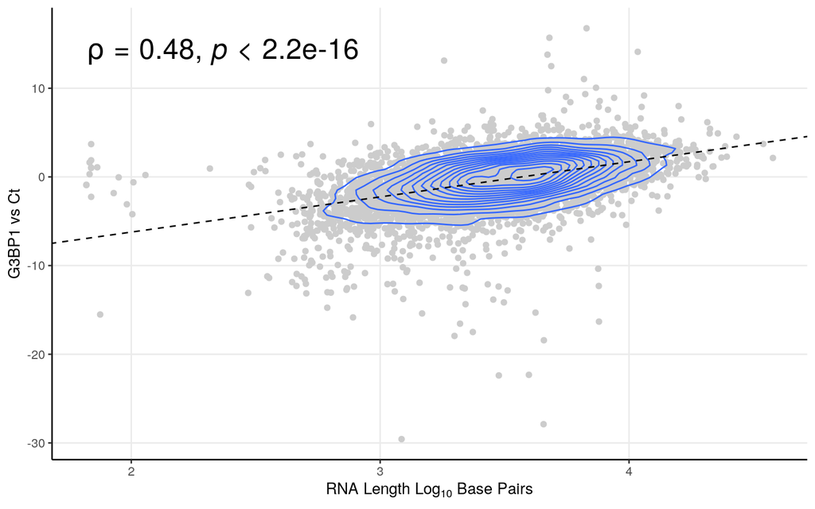

```r
smooth.SG <- lm(t~log10(Length), DEGenes_BP1.vs.CT)
liner.SG <- rstandard(smooth.SG)
DEGenes_BP1.vs.CT <-cbind(DEGenes_BP1.vs.CT, liner.SG)
colnames(DEGenes_BP1.vs.CT)[9] <- "Residuals"
row.names(DEGenes_BP1.vs.CT) <- DEGenes_BP1.vs.CT$Gene
linemarkers <- as.data.frame(DEGenes_BP1.vs.CT[abs(DEGenes_BP1.vs.CT$Residuals)>4,])

# Calculate the Spearman correlation coefficient
spearman_corr <- cor(DEGenes_BP1.vs.CT$t, log10(DEGenes_BP1.vs.CT$Length), method = "spearman")



ggplot(DEGenes_BP1.vs.CT, aes(y=t, x=log10(Length))) + geom_point(color="#CCCCCC", alpha=1) +   theme_bw()+ geom_density_2d()+
 ylab("G3BP1 vs Ct") + xlab(expression(RNA ~ Length ~ Log[10] ~ Base ~ Pairs)) +
  theme(axis.line = element_line(colour = "black"),
        panel.grid.minor = element_blank(),
        panel.border = element_blank(),
        panel.background = element_blank()) +
  theme(plot.title = element_text(hjust = 0.5))  +
  geom_abline(slope=smooth.SG$coefficients[2], intercept = smooth.SG$coefficients[1], linetype = "dashed")+ stat_cor(method = "spearman", cor.coef.name = "rho",size=7)
```

We see a bias towards longer transcripts.

## Expression Graphs (Extra QC)

As an added control, lets plot these genes in regard to their expression, and contamination.

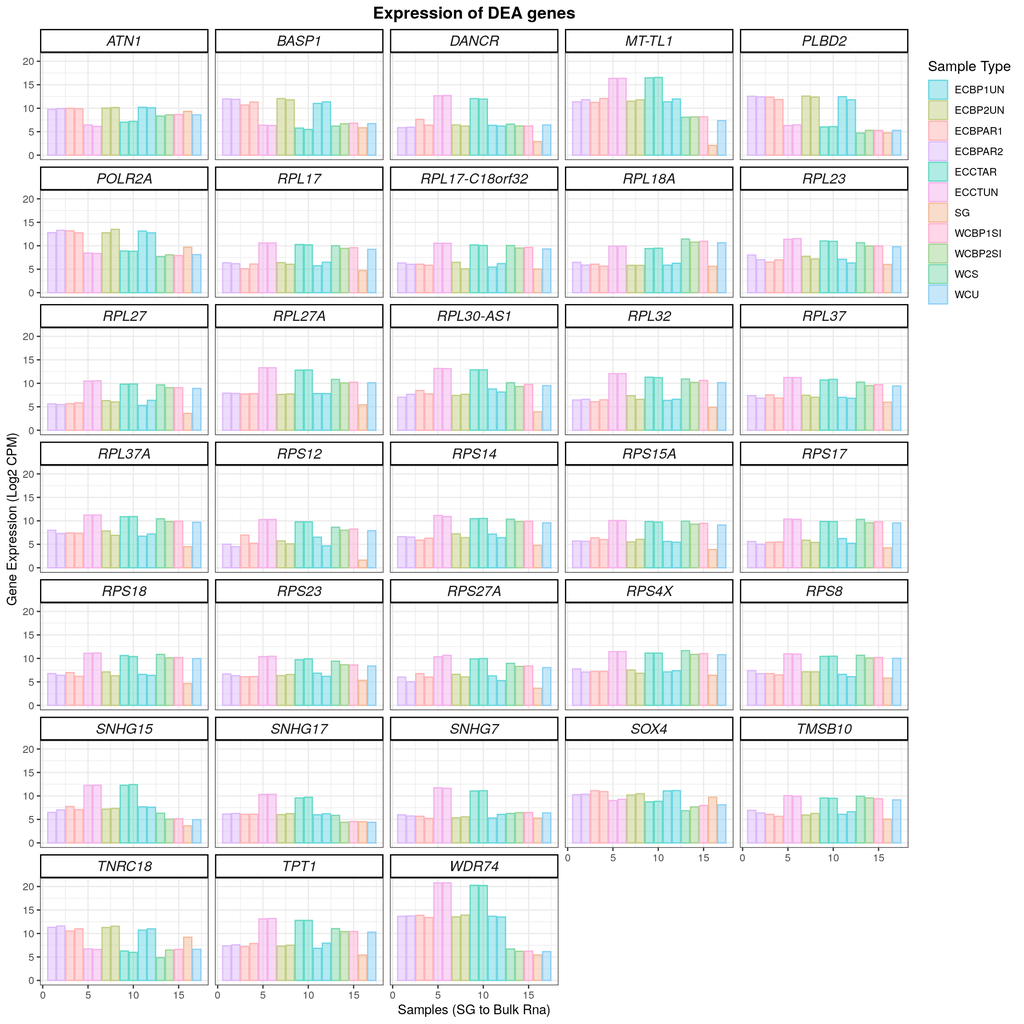

```r
upmarkers <- as.data.frame(DEGenes_BP1.vs.CT[DEGenes_BP1.vs.CT$logFC>2 & DEGenes_BP1.vs.CT$B>10,] )
downmarkers <- as.data.frame(DEGenes_BP1.vs.CT[DEGenes_BP1.vs.CT$logFC< -3.5 & DEGenes_BP1.vs.CT$B>10,] )

finagenes <- rbind(upmarkers, downmarkers)

dfforexpression <- dfforpca[-c(1:2),]
samplecodes <- data.frame(samples=row.names(dfforexpression), purity=c(1:17))
sampletype <- data.frame(samples=row.names(dfforexpression), sampletype=fordescriptive)
dfforexpression <- t(dfforexpression)
genesforexp <- dfforexpression[row.names(dfforexpression)%in%row.names(finagenes),]
genesforexp <- reshape2::melt(genesforexp)
colnames(genesforexp) <- c("Gene", "samples", "expression")
genesforexp <- merge(genesforexp, samplecodes, by="samples")
genesforexp <- merge(genesforexp, sampletype, by="samples")
genesforexp <- genesforexp[,-1]
genesforexp[,2] <- as.numeric(genesforexp[,2])
genesforexp[,1] <- as.character(genesforexp[,1])
genesforexp <- genesforexp[order(genesforexp$Gene),]


winnyplot <- ggplot(genesforexp, aes(x=purity, y=expression, fill=sampletype, colour=sampletype)) + geom_bar(position="dodge", stat="identity", alpha=0.5) + facet_wrap(.~ Gene, ncol=5)
winnyplot <- winnyplot + scale_fill_manual(name = "Sample Type", values = custom_palette) + scale_colour_manual(name = "Sample Type", values = custom_palette)
winnyplot <- winnyplot + theme_bw() + xlab("Samples (SG to Bulk Rna)") + ylab("Gene Expression (Log2 CPM)") + theme(
      strip.text.x = element_text(
        size = 12, face="italic"
        )) +
 theme(
   strip.background = element_rect(
     color="black", fill="#FFFFFF", size=1, linetype="solid"
     )
   ) + theme(
    #legend.position = c(.95, .40),
    legend.justification = c("right", "top"),
    legend.box.just = "right",
    ) + theme(legend.title = element_text(size = 12)) + ggtitle("Expression of DEA genes") + theme(plot.title = element_text(hjust = 0.5, size=14, face="bold"))
winnyplot
```

## GSEA

Now that we have our genes of interest, it would also be interesting to see what are the **altered gene sets** between upregulated and downregulated transcripts from the above comparison. Therefore, lets perform a *Gene Set Enrichment Analysis*

```r
#for all genes
DEGenes_BP1.vs.CT <- DEGenes_BP1.vs.CT[order(DEGenes_BP1.vs.CT[,4]),]
gseatool <- DEGenes_BP1.vs.CT[,4]
gseatool <- as.data.frame(gseatool)
colnames(gseatool)[1] <- "t"
gseatool[,2] <- DEGenes_BP1.vs.CT$Gene
colnames(gseatool)[2] <- "Symbol"
gseatool <- gseatool[,c(2,1)]

vectorranks <- gseatool$t
names(vectorranks) <- gseatool$Symbol


#to load our pathways
hallmarks.gs <- msigdbr(species = "Homo sapiens", collection =  "H")

hallmarks.gsets <- hallmarks.gs %>% split(x = .$gene_symbol, f = .$gs_name)

for (set in names(hallmarks.gsets)){
  hallmarks.gsets[[set]] <- toupper(hallmarks.gsets[[set]])
}

hallmarks.res <- fgsea(pathways = hallmarks.gsets,
                       stats = vectorranks)
hallmarks.res.tidy <- hallmarks.res %>%
  as_tibble() %>%
  arrange(desc(NES))

hallmarks.res.tidy %>%
  dplyr::select(-leadingEdge, -ES) %>%
  arrange(padj)
```

```
## # A tibble: 50 × 6
##    pathway                                pval     padj log2err   NES  size
##    <chr>                                 <dbl>    <dbl>   <dbl> <dbl> <int>
##  1 HALLMARK_MYC_TARGETS_V1            4.46e-31 2.23e-29   1.45  -2.80   187
##  2 HALLMARK_OXIDATIVE_PHOSPHORYLATION 9.01e-20 2.25e-18   1.15  -2.58   160
##  3 HALLMARK_MTORC1_SIGNALING          4.61e- 9 7.68e- 8   0.761 -2.09   158
##  4 HALLMARK_E2F_TARGETS               4.93e- 7 4.93e- 6   0.659 -1.94   166
##  5 HALLMARK_UNFOLDED_PROTEIN_RESPONSE 3.97e- 7 4.93e- 6   0.675 -2.09    96
##  6 HALLMARK_G2M_CHECKPOINT            4.12e- 5 3.44e- 4   0.557 -1.76   163
##  7 HALLMARK_ALLOGRAFT_REJECTION       6.00e- 5 4.28e- 4   0.557 -1.94    43
##  8 HALLMARK_ADIPOGENESIS              1.66e- 4 9.68e- 4   0.519 -1.77   121
##  9 HALLMARK_MYC_TARGETS_V2            1.74e- 4 9.68e- 4   0.519 -1.90    51
## 10 HALLMARK_FATTY_ACID_METABOLISM     1.00e- 3 5.02e- 3   0.455 -1.76    92
## # ℹ 40 more rows
```

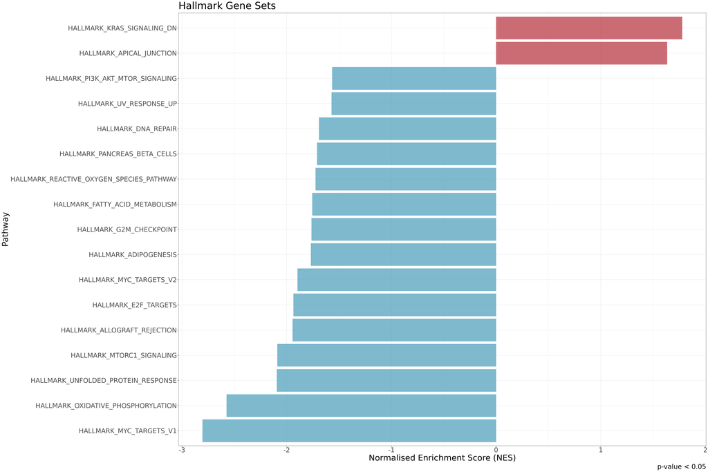

```r
hallmark.sg.t <- hallmarks.res.tidy[,c(1,6)]
hallmark.sg.t <- as.data.frame(hallmark.sg.t)

#this small part is generic
thresh <- 0.05

#this one is no longer generic
data_to_plot <- hallmarks.res.tidy %>% filter(padj < thresh)

statvec <- c()
for (i in 1:nrow(data_to_plot)){
  if (data_to_plot[i,6] > 0){
    status <- "Upregulated"
  }
 else {
   status <- "Downregulated"
 }
statvec <- c(statvec, status)
}

data_to_plot$Status <- statvec

##-----HALMARK-----
gsea_plot_hall <- ggplot(data_to_plot, aes(reorder(pathway, NES), NES)) +
  geom_col(aes(fill= Status), alpha=0.75) + scale_fill_manual(values = c("#53A2BE","#BA3B46"), name = "Regulation Status", labels = c("Downregulated", "Upregulated"), breaks = c("Downregulated", "Upregulated")) +
  coord_flip() +
  labs(x="Pathway", y="Normalised Enrichment Score (NES)",
       title= "Hallmark Gene Sets",
       caption = paste0("p-value < ", thresh)) + theme(plot.title = element_text(hjust = 1)) +
  theme_bw() + theme(text=element_text(family = "Quicksand")) + theme(legend.position = "none")

gsea_plot_hall+
  theme(text=element_text(size=25,  family="Arial MS"))
```

# SG vs WC

## Volcano Plot

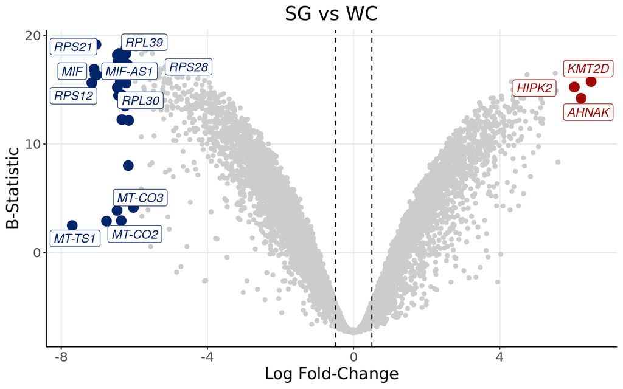

```r
write.table(x = DEGenes_SG.vs.WC,
file = "~/Projects/StressGranules/SGPAPER/SGvsWC/AlzhDC.txt", sep="\t", col.names = TRUE, row.names = TRUE, quote=FALSE)


ndegs <- 10
upmarkers <- as.data.frame(DEGenes_SG.vs.WC[DEGenes_SG.vs.WC$logFC>6 & DEGenes_SG.vs.WC$adj.P.Val<0.05,] )
downmarkers <- as.data.frame(DEGenes_SG.vs.WC[DEGenes_SG.vs.WC$logFC< -6 & DEGenes_SG.vs.WC$adj.P.Val<0.05,] )

ggplot(data=DEGenes_SG.vs.WC,
                 aes(x=logFC,
                     y=  B)) +
  geom_point(color="#CCCCCC")+ geom_vline(xintercept = -0.5, linetype="dashed")+geom_vline(xintercept = 0.5, linetype="dashed")+
  theme_bw() + ylab("B-Statistic")+xlab("Log Fold-Change")+
  theme(axis.line = element_line(colour = "black"),
        panel.grid.minor = element_blank(),
        panel.border = element_blank(),
        panel.background = element_blank()) +
  ggtitle("SG vs WC")+
  theme(plot.title = element_text(hjust = 0.5), plot.subtitle = element_text(hjust = 0.5)) +
  geom_point(data=upmarkers, aes(x=logFC, y=  B), color="#A10702",size=4)+
  geom_point(data=downmarkers, aes(x=logFC, y=  B), color="#03256C",size=4)+
  geom_label_repel(upmarkers[1:ndegs,] , mapping=aes(label=row.names(upmarkers)[1:ndegs]),size=4,point.padding=-0.5, color="#A10702",max.overlaps = 20, fontface="italic")+
  geom_label_repel(downmarkers[1:ndegs,] , mapping=aes(label=row.names(downmarkers)[1:ndegs]),size=4,point.padding=-0.5, color="#03256C",max.overlaps = 20, fontface="italic")+
  theme(text=element_text(size=15,  family="Arial MS"))
```

With DC method, we do get significance.

## Volcano Plot with Gene Length

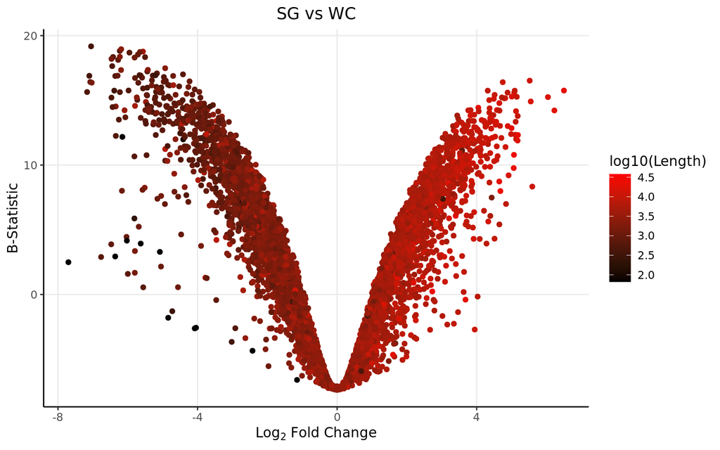

```r
DEGenes_SG.vs.WC$Gene <- row.names(DEGenes_SG.vs.WC)
colnames(genelength) <- c("Length","Gene")
DEGenes_SG.vs.WC <- merge(DEGenes_SG.vs.WC, genelength, by="Gene")

ggplot(data=DEGenes_SG.vs.WC,
                 aes(x=logFC,
                     y=  B)) +
  geom_point(aes(color=log10(Length)))+
  theme_bw() +
  theme(axis.line = element_line(colour = "black"),
        panel.grid.minor = element_blank(),
        panel.border = element_blank(),
        panel.background = element_blank()) +
  ggtitle("SG vs WC")+ xlab(expression(Log[2] ~ Fold ~ Change)) + ylab("B-Statistic") +
  theme(plot.title = element_text(hjust = 0.5))  +
  scale_colour_gradient(low = "black", high = "red")+ theme(text=element_text(family = "Quicksand"))
```

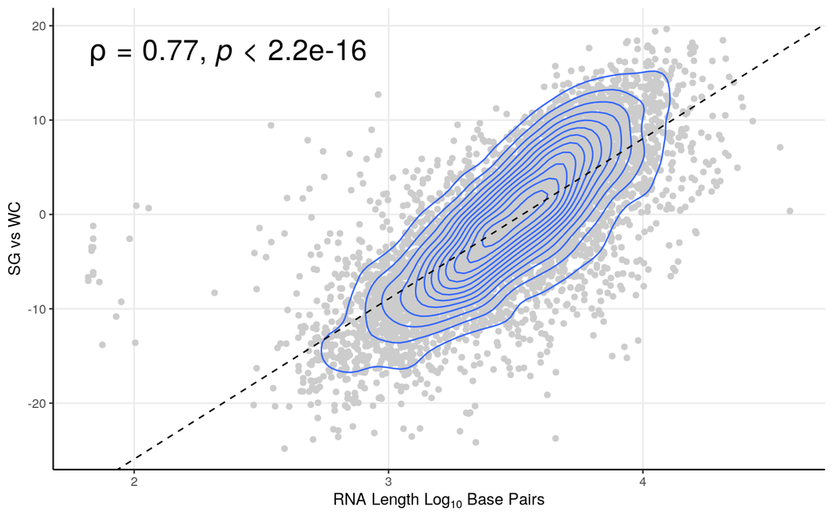

```r
smooth.SG <- lm(t~log10(Length), DEGenes_SG.vs.WC)
liner.SG <- rstandard(smooth.SG)
DEGenes_SG.vs.WC <-cbind(DEGenes_SG.vs.WC, liner.SG)
colnames(DEGenes_SG.vs.WC)[9] <- "Residuals"
row.names(DEGenes_SG.vs.WC) <- DEGenes_SG.vs.WC$Gene
linemarkers <- as.data.frame(DEGenes_SG.vs.WC[abs(DEGenes_SG.vs.WC$Residuals)>4,])

# Calculate the Spearman correlation coefficient
spearman_corr <- cor(DEGenes_SG.vs.WC$t, log10(DEGenes_SG.vs.WC$Length), method = "spearman")



ggplot(DEGenes_SG.vs.WC, aes(y=t, x=log10(Length))) + geom_point(color="#CCCCCC", alpha=1) +   theme_bw()+ geom_density_2d()+
 ylab("SG vs WC") + xlab(expression(RNA ~ Length ~ Log[10] ~ Base ~ Pairs)) +
  theme(axis.line = element_line(colour = "black"),
        panel.grid.minor = element_blank(),
        panel.border = element_blank(),
        panel.background = element_blank()) +
  theme(plot.title = element_text(hjust = 0.5))  +
  geom_abline(slope=smooth.SG$coefficients[2], intercept = smooth.SG$coefficients[1], linetype = "dashed")+ stat_cor(method = "spearman", cor.coef.name = "rho",size=7)
```

And as expected, whenever DC is used, we observe a bias towards long transcripts.

## Expression Graphs (Extra QC)

As an added control, lets plot these genes in regard to their expression, and contamination.

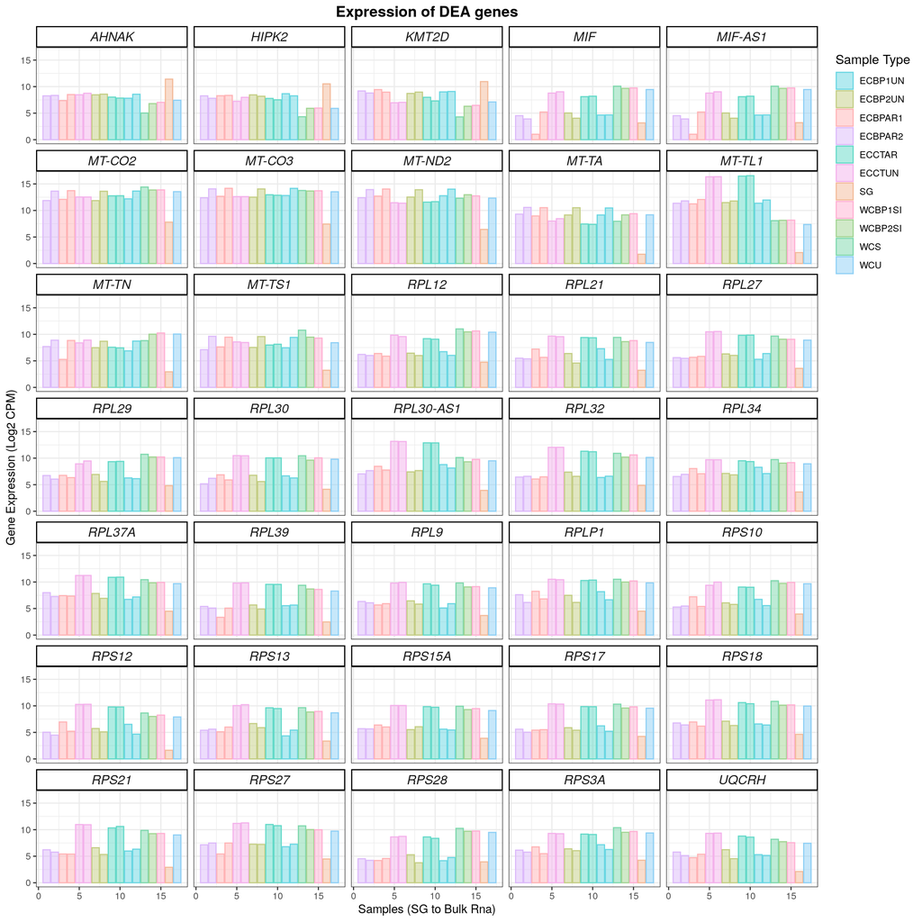

```r
upmarkers <- as.data.frame(DEGenes_SG.vs.WC[DEGenes_SG.vs.WC$logFC>6 & DEGenes_SG.vs.WC$adj.P.Val<0.05,] )
downmarkers <- as.data.frame(DEGenes_SG.vs.WC[DEGenes_SG.vs.WC$logFC< -6 & DEGenes_SG.vs.WC$adj.P.Val<0.05,] )

finagenes <- rbind(upmarkers, downmarkers)

dfforexpression <- dfforpca[-c(1:2),]
samplecodes <- data.frame(samples=row.names(dfforexpression), purity=c(1:17))
sampletype <- data.frame(samples=row.names(dfforexpression), sampletype=fordescriptive)
dfforexpression <- t(dfforexpression)
genesforexp <- dfforexpression[row.names(dfforexpression)%in%row.names(finagenes),]
genesforexp <- reshape2::melt(genesforexp)
colnames(genesforexp) <- c("Gene", "samples", "expression")
genesforexp <- merge(genesforexp, samplecodes, by="samples")
genesforexp <- merge(genesforexp, sampletype, by="samples")
genesforexp <- genesforexp[,-1]
genesforexp[,2] <- as.numeric(genesforexp[,2])
genesforexp[,1] <- as.character(genesforexp[,1])
genesforexp <- genesforexp[order(genesforexp$Gene),]


winnyplot <- ggplot(genesforexp, aes(x=purity, y=expression, fill=sampletype, colour=sampletype)) + geom_bar(position="dodge", stat="identity", alpha=0.5) + facet_wrap(.~ Gene, ncol=5)
winnyplot <- winnyplot + scale_fill_manual(name = "Sample Type", values = custom_palette) + scale_colour_manual(name = "Sample Type", values = custom_palette)
winnyplot <- winnyplot + theme_bw() + xlab("Samples (SG to Bulk Rna)") + ylab("Gene Expression (Log2 CPM)") + theme(
      strip.text.x = element_text(
        size = 12, face="italic"
        )) +
 theme(
   strip.background = element_rect(
     color="black", fill="#FFFFFF", size=1, linetype="solid"
     )
   ) + theme(
    #legend.position = c(.95, .40),
    legend.justification = c("right", "top"),
    legend.box.just = "right",
    ) + theme(legend.title = element_text(size = 12)) + ggtitle("Expression of DEA genes") + theme(plot.title = element_text(hjust = 0.5, size=14, face="bold"))
winnyplot
```

## GSEA

Now that we have our genes of interest, it would also be interesting to see what are the **altered gene sets** between upregulated and downregulated transcripts from the above comparison. Therefore, lets perform a *Gene Set Enrichment Analysis*

```r
#for all genes
DEGenes_SG.vs.WC <- DEGenes_SG.vs.WC[order(DEGenes_SG.vs.WC[,4]),]
gseatool <- DEGenes_SG.vs.WC[,4]
gseatool <- as.data.frame(gseatool)
colnames(gseatool)[1] <- "t"
gseatool[,2] <- DEGenes_SG.vs.WC$Gene
colnames(gseatool)[2] <- "Symbol"
gseatool <- gseatool[,c(2,1)]

vectorranks <- gseatool$t
names(vectorranks) <- gseatool$Symbol


#to load our pathways
hallmarks.gs <- msigdbr(species = "Homo sapiens", collection =  "H")

hallmarks.gsets <- hallmarks.gs %>% split(x = .$gene_symbol, f = .$gs_name)

for (set in names(hallmarks.gsets)){
  hallmarks.gsets[[set]] <- toupper(hallmarks.gsets[[set]])
}

hallmarks.res <- fgsea(pathways = hallmarks.gsets,
                       stats = vectorranks)
hallmarks.res.tidy <- hallmarks.res %>%
  as_tibble() %>%
  arrange(desc(NES))

hallmarks.res.tidy %>%
  dplyr::select(-leadingEdge, -ES) %>%
  arrange(padj)
```

```
## # A tibble: 50 × 6
##    pathway                                pval     padj log2err   NES  size
##    <chr>                                 <dbl>    <dbl>   <dbl> <dbl> <int>
##  1 HALLMARK_OXIDATIVE_PHOSPHORYLATION 3.29e-33 1.65e-31   1.50  -3.08   160
##  2 HALLMARK_MYC_TARGETS_V1            2.57e-22 6.43e-21   1.22  -2.70   187
##  3 HALLMARK_MITOTIC_SPINDLE           1.02e-10 1.71e- 9   0.839  2.33   141
##  4 HALLMARK_DNA_REPAIR                1.65e- 9 2.07e- 8   0.788 -2.26   116
##  5 HALLMARK_FATTY_ACID_METABOLISM     6.09e- 9 6.09e- 8   0.761 -2.26    92
##  6 HALLMARK_UV_RESPONSE_DN            5.36e- 8 4.24e- 7   0.720  2.42    60
##  7 HALLMARK_ADIPOGENESIS              5.94e- 8 4.24e- 7   0.720 -2.10   121
##  8 HALLMARK_MYC_TARGETS_V2            2.08e- 4 1.30e- 3   0.519 -1.90    51
##  9 HALLMARK_MTORC1_SIGNALING          3.36e- 4 1.87e- 3   0.498 -1.64   158
## 10 HALLMARK_KRAS_SIGNALING_UP         6.84e- 4 3.42e- 3   0.477  1.84    49
## # ℹ 40 more rows
```

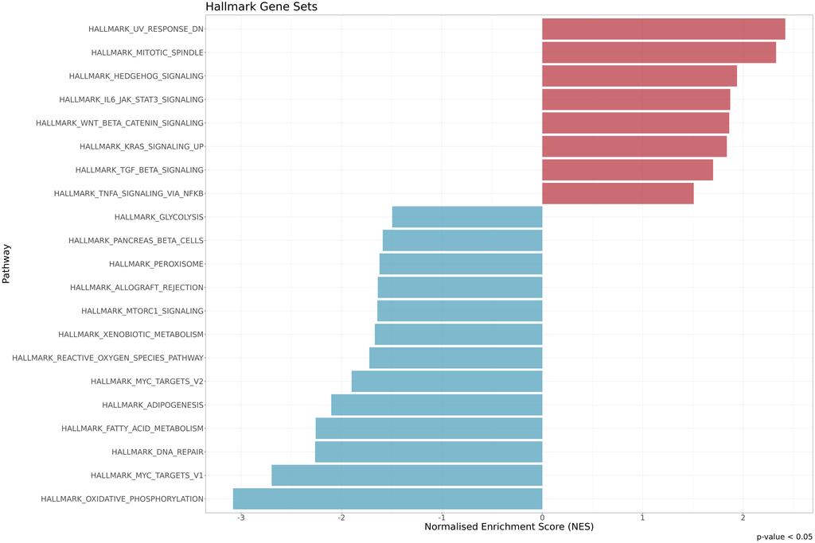

```r
hallmark.sg.t <- hallmarks.res.tidy[,c(1,6)]
hallmark.sg.t <- as.data.frame(hallmark.sg.t)

#this small part is generic
thresh <- 0.05

#this one is no longer generic
data_to_plot <- hallmarks.res.tidy %>% filter(padj < thresh)

statvec <- c()
for (i in 1:nrow(data_to_plot)){
  if (data_to_plot[i,6] > 0){
    status <- "Upregulated"
  }
 else {
   status <- "Downregulated"
 }
statvec <- c(statvec, status)
}

data_to_plot$Status <- statvec

##-----HALMARK-----
gsea_plot_hall <- ggplot(data_to_plot, aes(reorder(pathway, NES), NES)) +
  geom_col(aes(fill= Status), alpha=0.75) + scale_fill_manual(values = c("#53A2BE","#BA3B46"), name = "Regulation Status", labels = c("Downregulated", "Upregulated"), breaks = c("Downregulated", "Upregulated")) +
  coord_flip() +
  labs(x="Pathway", y="Normalised Enrichment Score (NES)",
       title= "Hallmark Gene Sets",
       caption = paste0("p-value < ", thresh)) + theme(plot.title = element_text(hjust = 1)) +
  theme_bw() + theme(text=element_text(family = "Quicksand")) + theme(legend.position = "none")

gsea_plot_hall+
  theme(text=element_text(size=25,  family="Arial MS"))
```

# G3BP2 eclip vs Control (stressed)

## Volcano Plot

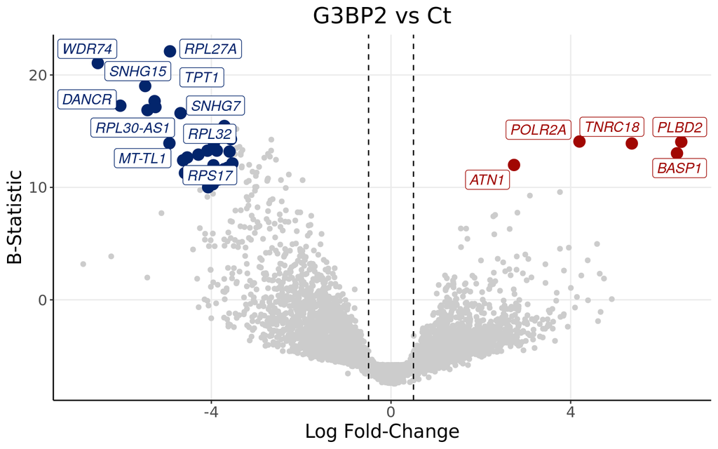

```r
ndegs <- 10
upmarkers <- as.data.frame(DEGenes_BP2.vs.CT[DEGenes_BP2.vs.CT$logFC>2 & DEGenes_BP2.vs.CT$B>10,] )
downmarkers <- as.data.frame(DEGenes_BP2.vs.CT[DEGenes_BP2.vs.CT$logFC< -3.5 & DEGenes_BP2.vs.CT$B>10,] )

ggplot(data=DEGenes_BP2.vs.CT,
                 aes(x=logFC,
                     y=  B)) +
  geom_point(color="#CCCCCC")+ geom_vline(xintercept = -0.5, linetype="dashed")+geom_vline(xintercept = 0.5, linetype="dashed")+
  theme_bw() + ylab("B-Statistic")+xlab("Log Fold-Change")+
  theme(axis.line = element_line(colour = "black"),
        panel.grid.minor = element_blank(),
        panel.border = element_blank(),
        panel.background = element_blank()) +
  ggtitle("G3BP2 vs Ct")+
  theme(plot.title = element_text(hjust = 0.5), plot.subtitle = element_text(hjust = 0.5)) +
  geom_point(data=upmarkers, aes(x=logFC, y=  B), color="#A10702",size=4)+
  geom_point(data=downmarkers, aes(x=logFC, y=  B), color="#03256C",size=4)+
  geom_label_repel(upmarkers[1:ndegs,] , mapping=aes(label=row.names(upmarkers)[1:ndegs]),size=4,point.padding=-0.5, color="#A10702",max.overlaps = 20, fontface="italic")+
  geom_label_repel(downmarkers[1:ndegs,] , mapping=aes(label=row.names(downmarkers)[1:ndegs]),size=4,point.padding=-0.5, color="#03256C",max.overlaps = 20, fontface="italic")+
  theme(text=element_text(size=15,  family="Arial MS"))
```